# Análisis AIRBNB

Grupo 12

## Introducción y definición de objetivos

Durante estos últimos años, plataformas donde se reservan propiedades durante un tiempo determinado, como es Airbnb, han ido subiendo su popularidad, optando mucha gente por este tipo de servicio. Es por ello que un análisis de este modelo de negocio es interesante tanto para los clientes como para la empresa propietaria de Airbnb. Por ello, el principal objetivo de esta investigación es observar como afectan al precio las distintas variables.

Hemos descartado algunas variables dentro de esta base de datos. Comenzamos descartando las variables “latitud”, “longitud” y “zipcode”, ya que tienen que ver con la localización de la propiedad y eso ya se refleja con las variables “city” y “neighbourhood”. Otra variable descartada es “amenities” ya que contenía muchas más variables internas que complicarían el análisis. La variable “accomodates”, referida al número de personas que se alojan en la propiedad, decidimos descartarla porque hay otras variables que la hacen redundante. La variable “host_response_rate” (tasa de respuesta del anfitrión) la descartamos ya que en muchos de los casos no hay información. Variables como “first review” (fecha en la que se realizó la primera valoración), “last review” (fecha en la que se realizó la última valoración), “description” (descripción), “host_has_profile_pic” (si el anfitrión tiene foto de perfil en Airbnb), “host_since” (fecha en la que se publicó por primera vez la propiedad), “name” (nombre de la propiedad) o “thumbnail_url” (URL de la página de la propiedad), han sido descartadas porque no son relevantes para nuestro análisis.

## Importación de datos y paquetes usados

```r
library(dplyr)
library(readr)
library(tidyverse)
library(ggplot2)
library(summarytools)
library(GGally)
library(knitr)
library(ggcorrplot)
library(corrplot)
library(htmltools)

Airbnb_Data <- read_csv("Airbnb_Data.csv")
```

## Diccionario de datos

- `price` : Precio de la reserva de AIRBNB en dólares.
  - Tipo: Numérica continua.
- `property_type`: Tipo de propiedad que se reserva.
  - Tipo: Categórica multinivel.
- `room_type`: Tipo de habitación que incluye la reserva.
  - Tipo: Categórica multinivel.
- `bathrooms`: Número de baños que contiene la propiedad.
  - Tipo: Numérica continua.
- `bedrooms`: Número de habitaciones de la propiedad.
  - Tipo: Numérica discreta.
- `beds`: Número de camas de la propiedad.
  - Tipo: Numérica discreta.
- `bed_type`: Tipo de cama que ofrece la propiedad.
  - Tipo: Categórica multinivel.
- `cancellation_policy`: Tipo de política de cancelación.
  - Tipo: Categórica ordinal.
- `cleaning_fee`: Tarifa por limpieza.
  - Tipo: Categórica dicotómica. (TRUE, hay / FALSE, no hay)
- `city`: Ciudad de ubicación de la propiedad.
  - Tipo: Categórica multinivel.
- `neighbourhood`: Barrio de ubicación de la propiedad.
  - Tipo: Categórica multinivel.
- `host_identity_verified`: Anfitrión verificado en Airbnb.
  - Tipo: Categórica dicotómica. (TRUE, sí / FALSE, no)
- `instant_bookable`: Reservar la propiedad al instante.
  - Tipo: Categórica dicotómica. (TRUE, sí / FALSE, no)
- `number_of_reviews`: Número de reviews de la propiedad.
  - Tipo: Numérica discreta.
- `review_scores_rating`: Puntuación de las reviews de la propiedad.
  - Tipo: Numérica discreta.

## Análisis exploratorio de datos

Comenzamos realizando un estudio de todas las variables de manera univariante.

### Análisis univariante:

#### Estudio de la variable price

Antes de estudiar la variable price, observamos que esta se encuentra de forma logarítmica, por tanto, para verlo todo de manera más clara, simplemente invertimos el logaritmo para obtener precios con más sentido.

```r
Airbnb_Data$log_price = exp(Airbnb_Data$log_price)
```

A pesar de haber invertido el logaritmo, en la parte de código seguiremos referenciando esta variable como log_price, sin embargo, en las gráficas aparecerá como price en todo momento. Ahora sí comenzamos con el análisis de price.

CONTAR EL NÚMERO DE RESPUESTAS

```r
num_respuestas_PRICE <- length(unique(Airbnb_Data$log_price))
cat("La cantidad de respuestas obtenidas es:", num_respuestas_PRICE)
```

```
## La cantidad de respuestas obtenidas es: 767
```

Dada la alta cantidad de respuestas distintas, para poder visualizar todo en una tabla de frecuencias de manera medianamente clara, procedemos a dividir los precios en intervalos de 25.

TABLA DE FRECUENCIAS

Estudiamos las frecuencias relativas y absolutas.

```r
intervalos <- seq(0, ceiling(max(Airbnb_Data$log_price)/25) * 25, by = 25)
tabla_frecuencias_price <- Airbnb_Data |> count(log_price) |> mutate(f = n / nrow(Airbnb_Data), N = cumsum(n), F = cumsum(f))
 tabla_frecuencias_price <- tabla_frecuencias_price |> mutate(Intervalo = cut(log_price, breaks = intervalos, right = FALSE)) |> group_by(Intervalo) |> summarise (n = sum(n), f = sum(f), N = sum(n), F = sum(f))
 for (i in 2: nrow(tabla_frecuencias_price)) {
   tabla_frecuencias_price$N[i] <- tabla_frecuencias_price$N[i] + tabla_frecuencias_price$N[i-1]
    tabla_frecuencias_price$F[i] <- tabla_frecuencias_price$F[i] + tabla_frecuencias_price$F[i-1]}
 tabla_frecuencias_ordenada1 <- tabla_frecuencias_price |> arrange(Intervalo)
 print(tabla_frecuencias_ordenada1)
```

```
## # A tibble: 75 × 5
##    Intervalo     n       f     N       F
##    <fct>     <int>   <dbl> <int>   <dbl>
##  1 [0,25)      343 0.00463   343 0.00463
##  2 [25,50)    6164 0.0832   6507 0.0878
##  3 [50,75)   14014 0.189   20521 0.277
##  4 [75,100)  11260 0.152   31781 0.429
##  5 [100,125)  8783 0.119   40564 0.547
##  6 [125,150)  6962 0.0939  47526 0.641
##  7 [150,175)  5650 0.0762  53176 0.718
##  8 [175,200)  6807 0.0918  59983 0.809
##  9 [200,225)  1857 0.0251  61840 0.834
## 10 [225,250)  2706 0.0365  64546 0.871
## # ℹ 65 more rows
```

HISTOGRAMA DE PRECIOS

Ahora realizamos el histograma para verlo mucho más claro.

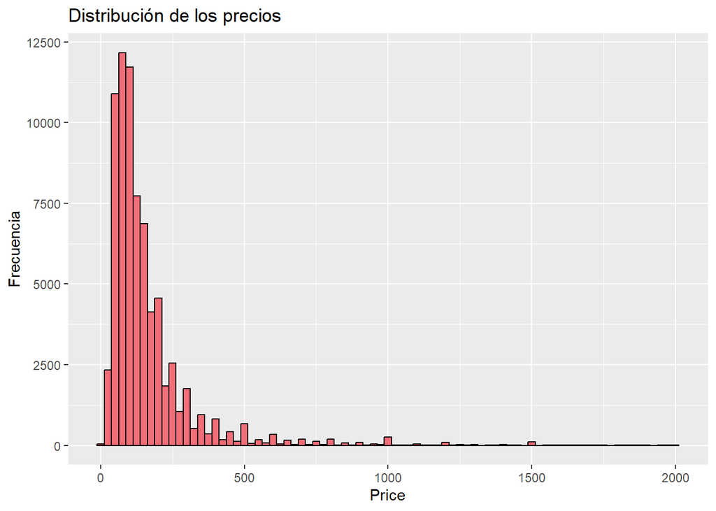

```r
datos <- Airbnb_Data$log_price
 ggplot(data.frame(x = datos), aes(x = x)) +
     geom_histogram(binwidth = 25, fill = "#F16E79", color = "black",
                    ) +

     labs(title = "Distribución de los precios",
          x = "Price",
          y = "Frecuencia")
```

Como podemos observar, la mayor parte de los precios se encuentra por debajo de los 300$, donde se ve una clara curva descendente según el precio va aumentando, llegando hasta un máximo de unos 2000$.

RESUMEN NUMÉRICO DE LOS PRECIOS

Es necesario realizar también un resumen numérico para poder interpretar mejor el histograma.

```r
Airbnb_Data |> select(log_price) |> descr() |> kable(digits = 2)
```

|  | log_price |
| --- | --- |
| Mean | 160.37 |
| Std.Dev | 168.58 |
| Min | 1.00 |
| Q1 | 75.00 |
| Median | 111.00 |
| Q3 | 185.00 |
| Max | 1999.00 |
| MAD | 68.20 |
| IQR | 110.00 |
| CV | 1.05 |
| Skewness | 4.30 |
| SE.Skewness | 0.01 |
| Kurtosis | 26.55 |
| N.Valid | 74111.00 |
| Pct.Valid | 100.00 |

Igual que hemos visto en el histograma, el resumen numérico nos demuestra que la mayor parte de los precios se concentran entre 1$ y los 185$, con una media de 160.37$ y una mediana de 111$. El precio mínimo es de 1$ y el máximo es de 1999$, aunque en muy pocos casos se dan estos valores.

#### Estudio de la variable property_type

CONTAR EL NÚMERO DE RESPUESTAS

```r
num_respuestas_TYPE <- length(unique(Airbnb_Data$property_type))
cat("La cantidad de respuestas obtenidas es:", num_respuestas_TYPE)
```

```
## La cantidad de respuestas obtenidas es: 35
```

Como podemos observar, aquí sí tiene sentido realizar un estudio para poder ver el tipo de casa que más se oferta.

TABLA DE FRECUENCIAS

Ahora estudiaremos las frecuencias relativas y absolutas.

```r
tabla_frecuencias_type <- Airbnb_Data |>
     count(property_type) |>
    mutate(f = n / nrow(Airbnb_Data), N = cumsum(n), F = cumsum(f))

tabla_frecuencias_ordenada2 <- tabla_frecuencias_type |>
    arrange(desc(n))

tabla_frecuencias_ordenada2$F <- cumsum(tabla_frecuencias_ordenada2$f)

tabla_frecuencias_ordenada2$N <- cumsum(tabla_frecuencias_ordenada2$n)

print(tabla_frecuencias_ordenada2)
```

```
## # A tibble: 35 × 5
##    property_type       n       f     N     F
##    <chr>           <int>   <dbl> <int> <dbl>
##  1 Apartment       49003 0.661   49003 0.661
##  2 House           16511 0.223   65514 0.884
##  3 Condominium      2658 0.0359  68172 0.920
##  4 Townhouse        1692 0.0228  69864 0.943
##  5 Loft             1244 0.0168  71108 0.959
##  6 Other             607 0.00819 71715 0.968
##  7 Guesthouse        498 0.00672 72213 0.974
##  8 Bed & Breakfast   462 0.00623 72675 0.981
##  9 Bungalow          366 0.00494 73041 0.986
## 10 Villa             179 0.00242 73220 0.988
## # ℹ 25 more rows
```

GRÁFICO DE BARRAS CON FRECUENCIA RELATIVA DE PROPERTY_TYPE

Para poder observar con mayor claridad los datos en función de la frecuencia relativa realizaremos una gráfica.

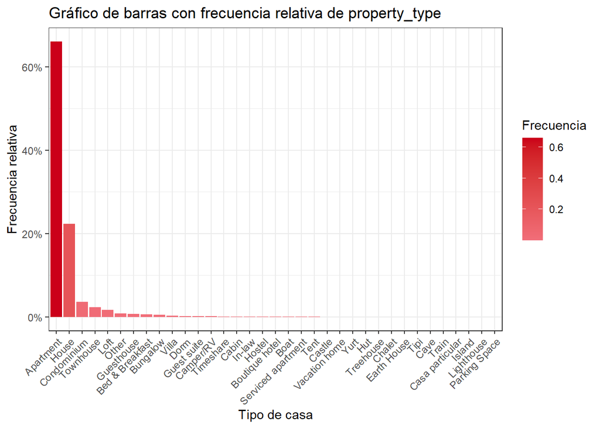

```r
Airbnb_Data |> group_by(property_type) |> summarise(Frequency = n()) |> mutate(Frequency = Frequency/sum(Frequency), property_type = reorder(property_type, -Frequency)) |> ggplot(aes(x = property_type, y = Frequency)) + geom_bar(stat = "identity", aes(fill = Frequency)) + scale_y_continuous(labels = scales::percent) + theme_bw() + labs(title = "Gráfico de barras con frecuencia relativa de property_type", x = "Tipo de casa", y = "Frecuencia relativa") + scale_fill_gradient("Frecuencia", low = "#F16E79", high = "#CB0019") + theme(axis.text.x = element_text(angle = 45, hjust = 1))
```

De la misma forma realizaremos una gráfica con los datos en función de la frecuencia absoluta.

GRÁFICO DE BARRAS CON FRECUENCIA ABSOLUTA DE PROPERTY_TYPE

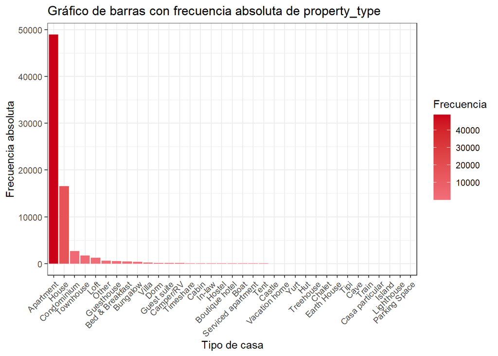

```r
Airbnb_Data |>
     group_by(property_type) |>
     summarise(Frequency = n()) |>
     mutate(property_type = reorder(property_type, -Frequency)) |>
    ggplot(aes(x = property_type, y = Frequency)) +
     geom_bar(stat = "identity", aes(fill = Frequency)) +
     theme_bw() +
     labs(title = "Gráfico de barras con frecuencia absoluta de property_type",
          x = "Tipo de casa",
          y = "Frecuencia absoluta") +
     scale_fill_gradient("Frecuencia", low = "#F16E79", high = "#CB0019") +
    theme(axis.text.x = element_text(angle = 45, hjust = 1))
```

#### Estudio de la variable room_type

CONTAR EL NÚMERO DE RESPUESTAS

```r
num_respuestas_TYPE <- length(unique(Airbnb_Data$room_type))
cat("La cantidad de respuestas obtenidas es:", num_respuestas_TYPE)
```

```
## La cantidad de respuestas obtenidas es: 3
```

Vamos a realizar el estudio para ver cuales son los tipos de habitaciones que más se ofertan en la plataforma.

TABLA DE FRECUENCIAS

Primero estudiaremos las frecuencias relativas y absolutas

```r
tabla_frecuencias_type <- Airbnb_Data |>
     count(room_type) |>
    mutate(f = n / nrow(Airbnb_Data), N = cumsum(n), F = cumsum(f))
 tabla_frecuencias_ordenada3 <- tabla_frecuencias_type |>
    arrange(desc(n))
 tabla_frecuencias_ordenada3$F <- cumsum(tabla_frecuencias_ordenada3$f)
 tabla_frecuencias_ordenada3$N <- cumsum(tabla_frecuencias_ordenada3$n)
 print(tabla_frecuencias_ordenada3)
```

```
## # A tibble: 3 × 5
##   room_type           n      f     N     F
##   <chr>           <int>  <dbl> <int> <dbl>
## 1 Entire home/apt 41310 0.557  41310 0.557
## 2 Private room    30638 0.413  71948 0.971
## 3 Shared room      2163 0.0292 74111 1
```

GRÁFICO DE BARRAS CON FRECUENCIA RELATIVA DE ROOM_TYPE

Para poder observar con mayor claridad los datos en función de la frecuencia relativa realizaremos una gráfica.

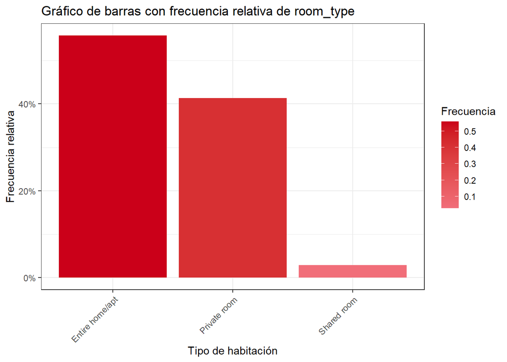

```r
Airbnb_Data  |> group_by(room_type) |>  summarise(Frequency = n()) |> mutate(Frequency = Frequency/sum(Frequency), room_type = reorder(room_type, -Frequency)) |> ggplot(aes(x = room_type, y = Frequency)) + geom_bar(stat = "identity", aes(fill = Frequency)) + scale_y_continuous(labels = scales::percent) + theme_bw() + labs(title = "Gráfico de barras con frecuencia relativa de room_type", x = "Tipo de habitación", y = "Frecuencia relativa") + scale_fill_gradient("Frecuencia", low = "#F16E79", high = "#CB0019") + theme(axis.text.x = element_text(angle = 45, hjust = 1))
```

GRÁFICO DE BARRAS CON FRECUENCIA ABSOLUTA DE ROOM_TYPE

De la misma forma realizaremos una gráfica con los datos en función de la frecuencia absoluta.

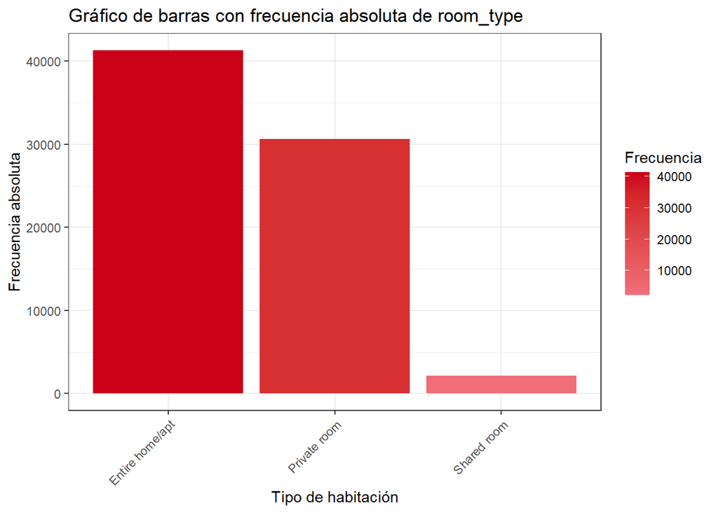

```r
Airbnb_Data  |> group_by(room_type) |>  summarise(Frequency = n()) |> mutate(room_type = reorder(room_type, -Frequency)) |> ggplot(aes(x = room_type, y = Frequency)) + geom_bar(stat = "identity", aes(fill = Frequency)) + theme_bw() + labs(title = "Gráfico de barras con frecuencia absoluta de room_type", x = "Tipo de habitación", y = "Frecuencia absoluta") + scale_fill_gradient("Frecuencia", low = "#F16E79", high = "#CB0019") + theme(axis.text.x = element_text(angle = 45, hjust = 1))
```

#### Estudio de la variable bathrooms

CONTAR EL NÚMERO DE RESPUESTAS

```r
num_respuestas_Bathrooms <- length(unique(Airbnb_Data$bathrooms))
cat("La cantidad de respuestas obtenidas es:", num_respuestas_Bathrooms)
```

```
## La cantidad de respuestas obtenidas es: 18
```

Aquí vamos a realizar un estudio para poder ver el número de baños que más se ofertan en la plataforma.

TABLA DE FRECUENCIAS

Estudiamos las frecuencias relativas y absolutas.

```r
tabla_frecuencias_bathrooms <- Airbnb_Data |> count(bathrooms) |> drop_na() |> mutate(f = n / nrow(Airbnb_Data), N = cumsum(n), F = cumsum(f))
tabla_frecuencias_ordenada4 <- tabla_frecuencias_bathrooms |>
    arrange(desc(n))
 tabla_frecuencias_ordenada4$F <- cumsum(tabla_frecuencias_ordenada4$f)
 tabla_frecuencias_ordenada4$N <- cumsum(tabla_frecuencias_ordenada4$n)
 print(tabla_frecuencias_ordenada4)
```

```
## # A tibble: 17 × 5
##    bathrooms     n         f     N     F
##        <dbl> <int>     <dbl> <int> <dbl>
##  1       1   58099 0.784     58099 0.784
##  2       2    7936 0.107     66035 0.891
##  3       1.5  3801 0.0513    69836 0.942
##  4       2.5  1567 0.0211    71403 0.963
##  5       3    1066 0.0144    72469 0.978
##  6       3.5   429 0.00579   72898 0.984
##  7       4     286 0.00386   73184 0.987
##  8       0.5   209 0.00282   73393 0.990
##  9       0     198 0.00267   73591 0.993
## 10       4.5   116 0.00157   73707 0.995
## 11       5      72 0.000972  73779 0.996
## 12       8      41 0.000553  73820 0.996
## 13       5.5    39 0.000526  73859 0.997
## 14       6      24 0.000324  73883 0.997
## 15       6.5    12 0.000162  73895 0.997
## 16       7      10 0.000135  73905 0.997
## 17       7.5     6 0.0000810 73911 0.997
```

HISTOGRAMA DEL NÚMERO DE BAÑOS

Vamos a realizar un histograma con el número de baños que se ofertan.

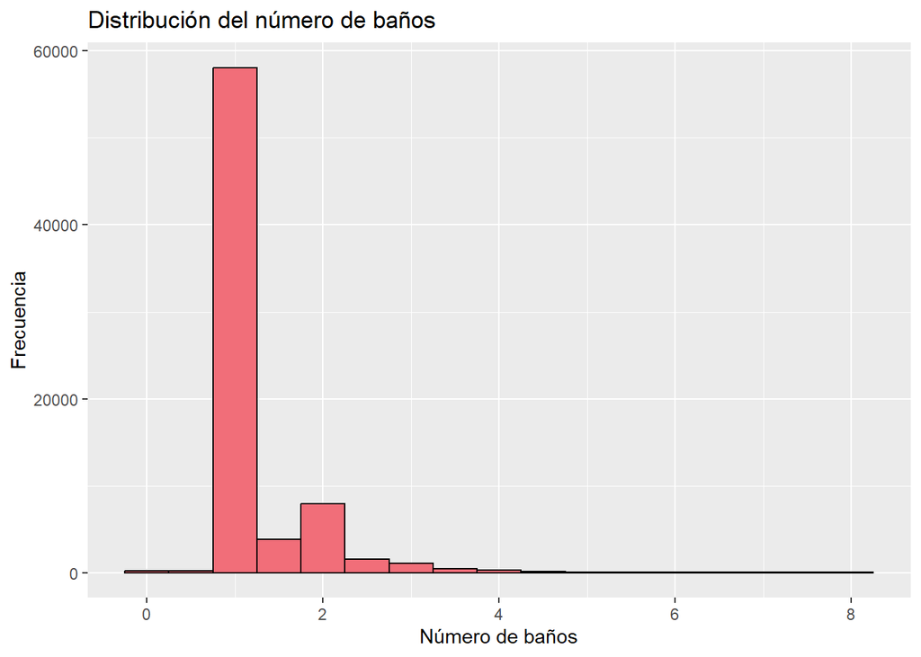

```r
datos <- Airbnb_Data$bathrooms
 ggplot(data.frame(x = datos), aes(x = x)) +
     geom_histogram(binwidth = 0.5, fill = "#F16E79", color = "black",
                    ) +

     labs(title = "Distribución del número de baños",
          x = "Número de baños",
          y = "Frecuencia")
```

Observamos una clara predominancia de propiedades con un solo baño, siendo también un tanto notables las propiedades con 1.5 y 2 baños. Hay casas con hasta 8 baños, pero es mísera la cantidad de propiedades que se venden con 4 o más de estos. También es sorprendente observar que, por pocas que sean, se oferten casas con 0 baños.

RESUMEN NUMÉRICO DEL NÚMERO DE BAÑOS

También vamos a realizar el resumen numérico que nos ayude a comprender mejor el gráfico.

```r
Airbnb_Data |> select(bathrooms) |> descr() |> kable(digits = 2)
```

|  | bathrooms |
| --- | --- |
| Mean | 1.24 |
| Std.Dev | 0.58 |
| Min | 0.00 |
| Q1 | 1.00 |
| Median | 1.00 |
| Q3 | 1.00 |
| Max | 8.00 |
| MAD | 0.00 |
| IQR | 0.00 |
| CV | 0.47 |
| Skewness | 3.69 |
| SE.Skewness | 0.01 |
| Kurtosis | 22.23 |
| N.Valid | 73911.00 |
| Pct.Valid | 99.73 |

Podemos observar que se usan decimales para hablar del número de baños, esto se debe a que para poder considerar un baño completo, este tiene que tener un lavabo, un inodoro, una ducha o bañera y un mueble de almacenamiento. El gráfico nos permite ver que la mayoría de ofertas solo tiene un baño, el mínimo de baños es 0 y el máximo son 8, y la media de baños que se ofertan son 1.25 baños.

#### Estudio de la variable bedrooms

CONTAR EL NÚMERO DE RESPUESTAS

```r
num_respuestas_bedrooms <- length(unique(Airbnb_Data$bedrooms))
cat("El número de respuestas obtenido es: ", num_respuestas_bedrooms)
```

```
## El número de respuestas obtenido es:  12
```

Vamos a realizar un estudio para ver las casas que se ofertan según el número de habitaciones.

TABLA DE FRECUENCIAS

Estudiamos las frecuencias relativas y absolutas.

```r
tabla_frecuencias_bedrooms <- Airbnb_Data |> count(bedrooms) |> drop_na() |> mutate(f = n / nrow(Airbnb_Data), N = cumsum(n), F = cumsum(f))
tabla_frecuencias_ordenada5 <- tabla_frecuencias_bedrooms |>
    arrange(desc(n))
 tabla_frecuencias_ordenada5$F <- cumsum(tabla_frecuencias_ordenada5$f)
 tabla_frecuencias_ordenada5$N <- cumsum(tabla_frecuencias_ordenada5$n)
 print(tabla_frecuencias_ordenada5)
```

```
## # A tibble: 11 × 5
##    bedrooms     n        f     N     F
##       <dbl> <int>    <dbl> <int> <dbl>
##  1        1 49784 0.672    49784 0.672
##  2        2 11351 0.153    61135 0.825
##  3        0  6715 0.0906   67850 0.916
##  4        3  4309 0.0581   72159 0.974
##  5        4  1330 0.0179   73489 0.992
##  6        5   355 0.00479  73844 0.996
##  7        6   106 0.00143  73950 0.998
##  8        7    38 0.000513 73988 0.998
##  9        8    14 0.000189 74002 0.999
## 10       10    10 0.000135 74012 0.999
## 11        9     8 0.000108 74020 0.999
```

HISTOGRAMA DEL NÚMERO DE HABITACIONES

Realizamos un histograma para verlo claramente.

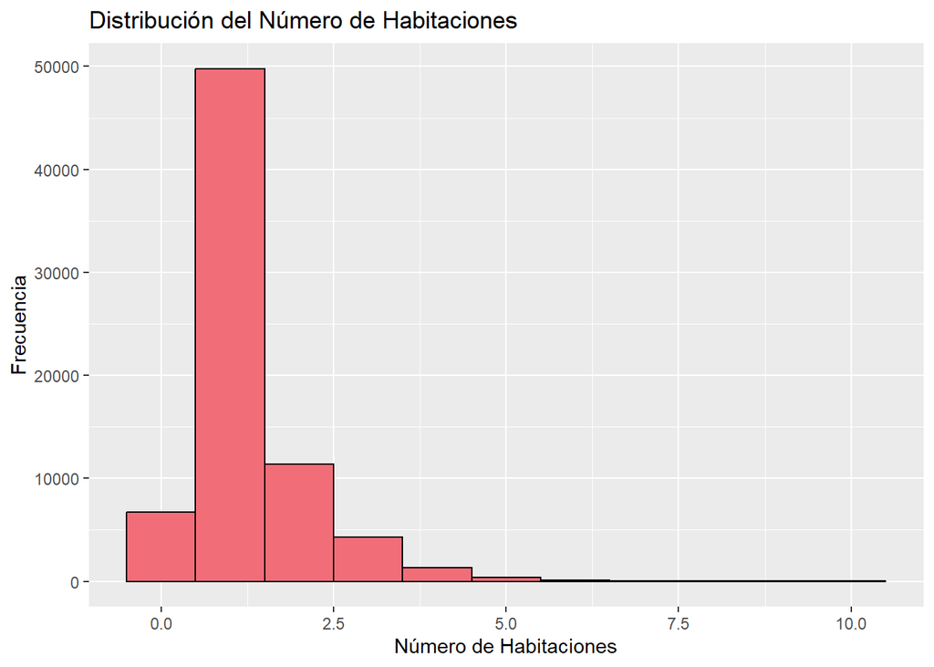

```r
datos <- Airbnb_Data$bedrooms
 ggplot(data.frame(x = datos), aes(x = x)) +
     geom_histogram(binwidth = 1, fill = "#F16E79", color = "black",
                    ) +

     labs(title = "Distribución del Número de Habitaciones",
          x = "Número de Habitaciones",
          y = "Frecuencia")
```

Observamos una destacable mayoría en la oferta de propiedades con una sola habitación. Muy por detrás se encuentran las propiedades con 2 habitaciones, seguidas de casas con 0 habitaciones, cosa que puede llegar a sorprender, sin embargo, ahora analizaremos el número de camas para ver que, aunque haya varias propiedades sin habitaciones, no significa que no tengan cama.

RESUMEN NUMÉRICO DEL NÚMERO DE HABITACIONES

```r
Airbnb_Data |> select(bedrooms) |> descr() |> kable(digits = 2)
```

|  | bedrooms |
| --- | --- |
| Mean | 1.27 |
| Std.Dev | 0.85 |
| Min | 0.00 |
| Q1 | 1.00 |
| Median | 1.00 |
| Q3 | 1.00 |
| Max | 10.00 |
| MAD | 0.00 |
| IQR | 0.00 |
| CV | 0.67 |
| Skewness | 1.99 |
| SE.Skewness | 0.01 |
| Kurtosis | 7.58 |
| N.Valid | 74020.00 |
| Pct.Valid | 99.88 |

Visto lo visto, comprobamos que la media está en 1.27, y la mediana en 1, pues la mayor parte de las propiedades tienen una habitación. Cabe destacar que el máximo se encuentra en hasta 10 habitaciones, valor sorprendente pero muy atípico, además de destacar ese mínimo en 0 que si que se da en bastantes casos.

#### Estudio de la variable beds

CONTAR EL NÚMERO DE RESPUESTAS

```r
num_respuestas_BEDS <- length(unique(Airbnb_Data$beds))
cat("La cantidad de respuestas obtenidas es:", num_respuestas_BEDS)
```

```
## La cantidad de respuestas obtenidas es: 19
```

TABLA DE FRECUENCIAS

Estudiamos las frecuencias relativas y absolutas.

```r
tabla_frecuencias_beds <- Airbnb_Data |> count(beds) |> drop_na() |> mutate(f = n / nrow(Airbnb_Data), N = cumsum(n), F = cumsum(f))
tabla_frecuencias_ordenada6 <- tabla_frecuencias_beds |>
    arrange(desc(n))
 tabla_frecuencias_ordenada6$F <- cumsum(tabla_frecuencias_ordenada6$f)
 tabla_frecuencias_ordenada6$N <- cumsum(tabla_frecuencias_ordenada6$n)
 print(tabla_frecuencias_ordenada6)
```

```
## # A tibble: 18 × 5
##     beds     n         f     N     F
##    <dbl> <int>     <dbl> <int> <dbl>
##  1     1 45144 0.609     45144 0.609
##  2     2 16704 0.225     61848 0.835
##  3     3  6442 0.0869    68290 0.921
##  4     4  3065 0.0414    71355 0.963
##  5     5  1287 0.0174    72642 0.980
##  6     6   661 0.00892   73303 0.989
##  7     7   216 0.00291   73519 0.992
##  8     8   186 0.00251   73705 0.995
##  9    10    88 0.00119   73793 0.996
## 10     9    72 0.000972  73865 0.997
## 11    16    38 0.000513  73903 0.997
## 12    12    29 0.000391  73932 0.998
## 13    11    23 0.000310  73955 0.998
## 14    13    10 0.000135  73965 0.998
## 15    15     6 0.0000810 73971 0.998
## 16     0     4 0.0000540 73975 0.998
## 17    14     4 0.0000540 73979 0.998
## 18    18     1 0.0000135 73980 0.998
```

HISTOGRAMA DEL NÚMERO DE CAMAS

Realizamos aquí un histograma para verlo más claro.

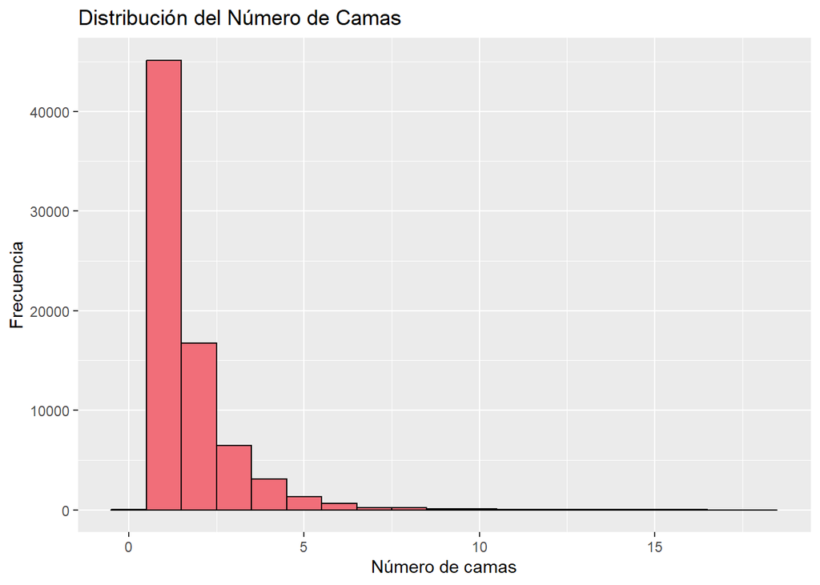

```r
datos <- Airbnb_Data$beds
 ggplot(data.frame(x = datos), aes(x = x)) +
     geom_histogram(binwidth = 1, fill = "#F16E79", color = "black",
                    ) +

     labs(title = "Distribución del Número de Camas",
          x = "Número de camas",
          y = "Frecuencia")
```

Aquí se ve que predomina enormemente la oferta de propiedades con una sola cama, seguido de las que tienen 2 camas, siendo menos de la mitad de las de una cama, y así sucesivamente según aumenta el número de camas.

ANÁLISIS NUMÉRICO

```r
Airbnb_Data |> select(beds) |> descr() |> kable(digits = 2)
```

|  | beds |
| --- | --- |
| Mean | 1.71 |
| Std.Dev | 1.25 |
| Min | 0.00 |
| Q1 | 1.00 |
| Median | 1.00 |
| Q3 | 2.00 |
| Max | 18.00 |
| MAD | 0.00 |
| IQR | 1.00 |
| CV | 0.73 |
| Skewness | 3.36 |
| SE.Skewness | 0.01 |
| Kurtosis | 19.72 |
| N.Valid | 73980.00 |
| Pct.Valid | 99.82 |

Llama la atención que el mínimo sea 0, es decir, que se oferten casas sin cama, sin embargo, este dato es muy atípico y es muy poco apreciable el porcentaje de propiedades con 0 camas, al igual que el máximo, que está en 18 camas. Tras ello observamos que la media está en 1.71 camas y la mediana en 1, el valor predominante.

#### Estudio de la variable bed_type

CONTAR EL NÚMERO DE RESPUESTAS

```r
num_respuestas_bed_type <- length(unique(Airbnb_Data$bed_type))
cat("El número de respuestas obtenido es: ", num_respuestas_bed_type)
```

```
## El número de respuestas obtenido es:  5
```

Aquí estudiaremos cuales son los tipos de camas que más se ofertan.

TABLA DE FRECUENCIAS

Primero estudiaremos las frecuencias relativas y absolutas.

```r
tabla_frec_bed_type <- Airbnb_Data |> count(bed_type) |> mutate (f = n/nrow(Airbnb_Data), N = cumsum(n), F = cumsum(f))
tabla_frec_ord_5 <- tabla_frec_bed_type |> arrange(desc(n))
tabla_frec_ord_5$N <- cumsum(tabla_frec_ord_5$n)
tabla_frec_ord_5$F <- cumsum(tabla_frec_ord_5$f)
print(tabla_frec_ord_5)
```

```
## # A tibble: 5 × 5
##   bed_type          n       f     N     F
##   <chr>         <int>   <dbl> <int> <dbl>
## 1 Real Bed      72028 0.972   72028 0.972
## 2 Futon           753 0.0102  72781 0.982
## 3 Pull-out Sofa   585 0.00789 73366 0.990
## 4 Airbed          477 0.00644 73843 0.996
## 5 Couch           268 0.00362 74111 1
```

GRÁFICO DE BARRAS CON FRECUENCIA RELATIVA

Para poder observar los datos en función de frecuencia relativa con mayor claridad realizaremos una gráfica.

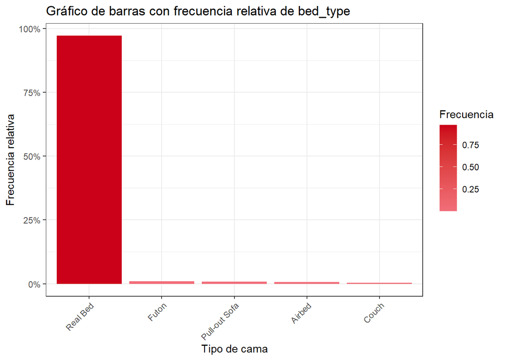

```r
Airbnb_Data  |> group_by(bed_type) |>  summarise(Frequency = n()) |> mutate(Frequency = Frequency/sum(Frequency), bed_type = reorder(bed_type, -Frequency)) |> ggplot(aes(x = bed_type, y = Frequency)) + geom_bar(stat = "identity", aes(fill = Frequency)) + scale_y_continuous(labels = scales::percent) + theme_bw() + labs(title = "Gráfico de barras con frecuencia relativa de bed_type", x = "Tipo de cama", y = "Frecuencia relativa") + scale_fill_gradient("Frecuencia", low = "#F16E79", high = "#CB0019") + theme(axis.text.x = element_text(angle = 45, hjust = 1))
```

GRÁFICO DE BARRAS CON FRECUENCIA ABSOLUTA

De la misma forma realizaremos un gráfico con las frecuencias absolutas.

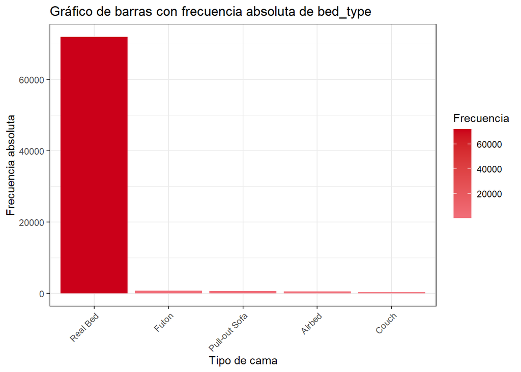

```r
Airbnb_Data  |> group_by(bed_type) |>  summarise(Frequency = n()) |> mutate(bed_type = reorder(bed_type, -Frequency)) |> ggplot(aes(x = bed_type, y = Frequency)) + geom_bar(stat = "identity", aes(fill = Frequency)) + theme_bw() + labs(title = "Gráfico de barras con frecuencia absoluta de bed_type", x = "Tipo de cama", y = "Frecuencia absoluta") + scale_fill_gradient("Frecuencia", low = "#F16E79", high = "#CB0019") + theme(axis.text.x = element_text(angle = 45, hjust = 1))
```

Como podemos observar en los gráficos, casi el 100% de las camas son camas normales, y son muy pocas las ofertas que tiene algún otro tipo de cama.

#### Estudio de la variable cancellation_policy

CONTAR EL NÚMERO DE RESPUESTAS

```r
num_respuestas_cancellation_policy <- length(unique(Airbnb_Data$cancellation_policy))
cat("El número de respuestas es: ", num_respuestas_cancellation_policy)
```

```
## El número de respuestas es:  5
```

Aquí vamos a estudiar cuales son las políticas de cancelación más presentes en la plataforma.

TABLA DE FRECUENCIAS

Primero estudiaremos las frecuencias relativas y absolutas.

```r
tabla_frecuencias_cancellation_policy <- Airbnb_Data |> count(cancellation_policy) |> drop_na() |> mutate(f = n / nrow(Airbnb_Data), N = cumsum(n), F = cumsum(f))
tabla_frecuencias_ordenada6 <- tabla_frecuencias_cancellation_policy |>
    arrange(desc(n))
 tabla_frecuencias_ordenada6$F <- cumsum(tabla_frecuencias_ordenada6$f)
 tabla_frecuencias_ordenada6$N <- cumsum(tabla_frecuencias_ordenada6$n)
 print(tabla_frecuencias_ordenada6)
```

```
## # A tibble: 5 × 5
##   cancellation_policy     n        f     N     F
##   <chr>               <int>    <dbl> <int> <dbl>
## 1 strict              32374 0.437    32374 0.437
## 2 flexible            22545 0.304    54919 0.741
## 3 moderate            19063 0.257    73982 0.998
## 4 super_strict_30       112 0.00151  74094 1.00
## 5 super_strict_60        17 0.000229 74111 1
```

GRÁFICO DE BARRAS CON FRECUENCIA RELATIVA

Para ello vamos a realizar un gráfico para poder entender mejor los datos en función de frecuencia relativa.

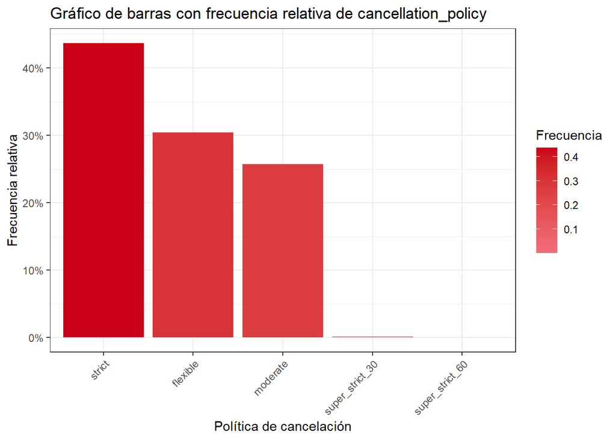

```r
Airbnb_Data  |> group_by(cancellation_policy) |>  summarise(Frequency = n()) |> mutate(Frequency = Frequency/sum(Frequency), cancellation_policy = reorder(cancellation_policy, -Frequency)) |> ggplot(aes(x = cancellation_policy, y = Frequency)) + geom_bar(stat = "identity", aes(fill = Frequency)) + scale_y_continuous(labels = scales::percent) + theme_bw() + labs(title = "Gráfico de barras con frecuencia relativa de cancellation_policy", x = "Política de cancelación", y = "Frecuencia relativa") + scale_fill_gradient("Frecuencia", low = "#F16E79", high = "#CB0019") + theme(axis.text.x = element_text(angle = 45, hjust = 1))
```

GRÁFICO DE BARRAS CON FRECUENCIA ABSOLUTA

De la misma forma vamos a realizar un gráfico con las frecuencias absolutas de las políticas de cancelación.

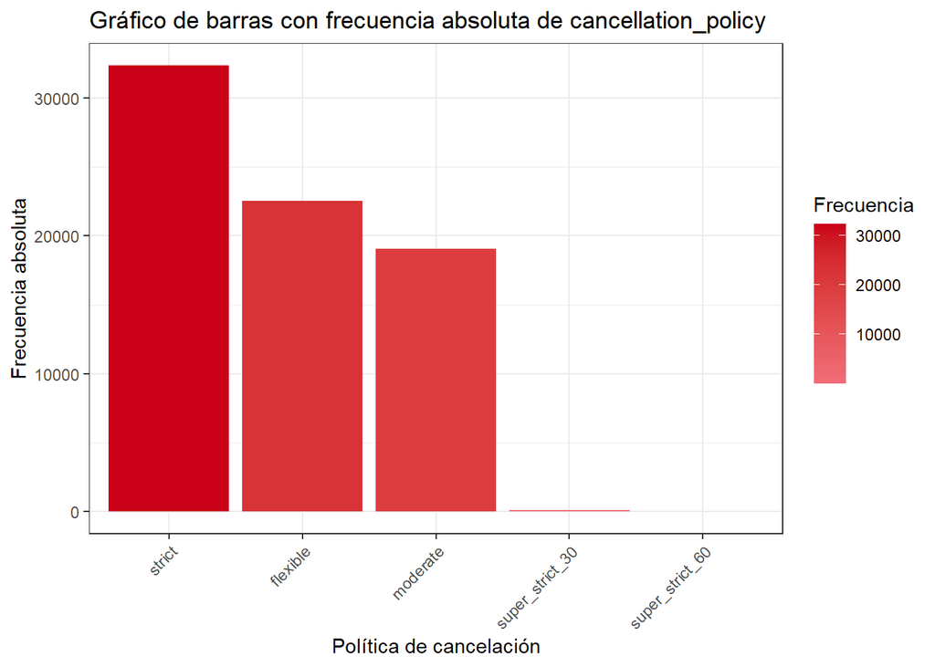

```r
Airbnb_Data  |> group_by(cancellation_policy) |>  summarise(Frequency = n()) |> mutate(cancellation_policy = reorder(cancellation_policy, -Frequency)) |> ggplot(aes(x = cancellation_policy, y = Frequency)) + geom_bar(stat = "identity", aes(fill = Frequency)) + theme_bw() + labs(title = "Gráfico de barras con frecuencia absoluta de cancellation_policy", x = "Política de cancelación", y = "Frecuencia absoluta") + scale_fill_gradient("Frecuencia", low = "#F16E79", high = "#CB0019") + theme(axis.text.x = element_text(angle = 45, hjust = 1))
```

Estos gráficos nos muestran que la mayoría de los ofertantes son estrictos en cuanto a su política de cancelación, con alrededor del 44% del total de datos, de cerca les siguen los ofertantes con una política flexible y moderada con un 30% y 26% respectivamente, y con mucha diferencia se encuentran el resto de políticas.

#### Estudio de la variable cleaning_fee

Vamos a estudiar la variable cleaning_fee.

CONTAR EL NÚMERO DE RESPUESTAS

```r
num_respuestas_cleaning_fee <- length(unique(Airbnb_Data$cleaning_fee))
cat("El número de respuestas obtenido es: ", num_respuestas_cleaning_fee)
```

```
## El número de respuestas obtenido es:  2
```

TABLA DE FRECUENCIAS

Para ello estudiamos las frecuencias relativas y absolutas.

```r
tabla_frec_cleaning_fee <- Airbnb_Data |> count(cleaning_fee) |> mutate(f = n/nrow(Airbnb_Data), N = cumsum(n), F = cumsum(f))
tabla_frec_ord_7 <- tabla_frec_cleaning_fee |> arrange(desc(n))
tabla_frec_ord_7$N <- cumsum(tabla_frec_ord_7$n)
tabla_frec_ord_7$F <- cumsum(tabla_frec_ord_7$f)
print(tabla_frec_ord_7)
```

```
## # A tibble: 2 × 5
##   cleaning_fee     n     f     N     F
##   <lgl>        <int> <dbl> <int> <dbl>
## 1 TRUE         54403 0.734 54403 0.734
## 2 FALSE        19708 0.266 74111 1
```

GRÁFICO DE BARRAS CON FRECUENCIA RELATIVA

Para entender mejor los datos vamos a realizar un gráfico de barras con frecuencia relativa de esta variable.

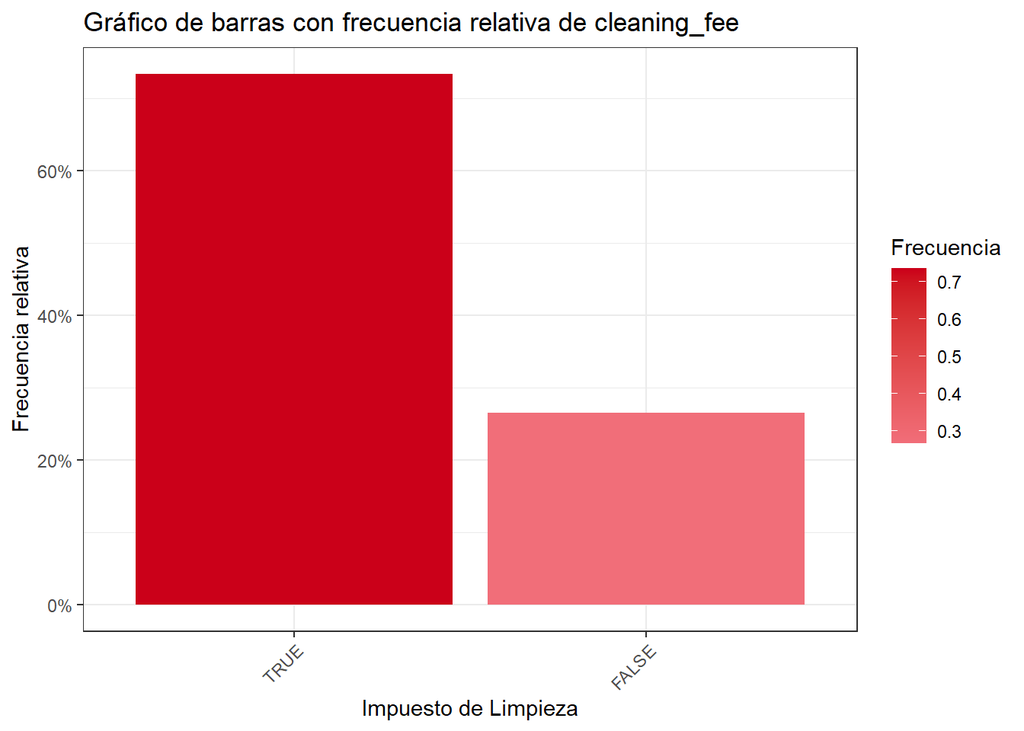

```r
Airbnb_Data  |> group_by(cleaning_fee) |>  summarise(Frequency = n()) |> mutate(Frequency = Frequency/sum(Frequency), cleaning_fee = reorder(cleaning_fee, -Frequency)) |> ggplot(aes(x = cleaning_fee, y = Frequency)) + geom_bar(stat = "identity", aes(fill = Frequency)) + scale_y_continuous(labels = scales::percent) + theme_bw() + labs(title = "Gráfico de barras con frecuencia relativa de cleaning_fee", x = "Impuesto de Limpieza", y = "Frecuencia relativa") + scale_fill_gradient("Frecuencia", low = "#F16E79", high = "#CB0019") + theme(axis.text.x = element_text(angle = 45, hjust = 1))
```

GRÁFICO DE BARRAS CON FRECUENCIA ABSOLUTA

Del mismo modo vamos a realizar otro gráfico de barras, pero esta vez de frecuencia absoluta.

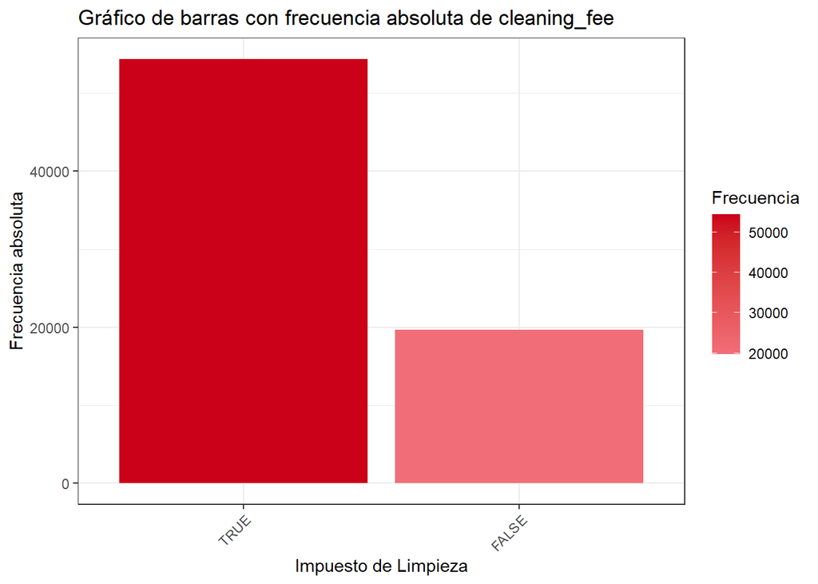

```r
Airbnb_Data  |> group_by(cleaning_fee) |>  summarise(Frequency = n()) |> mutate(cleaning_fee = reorder(cleaning_fee, -Frequency)) |> ggplot(aes(x = cleaning_fee, y = Frequency)) + geom_bar(stat = "identity", aes(fill = Frequency)) + theme_bw() + labs(title = "Gráfico de barras con frecuencia absoluta de cleaning_fee", x = "Impuesto de Limpieza", y = "Frecuencia absoluta") + scale_fill_gradient("Frecuencia", low = "#F16E79", high = "#CB0019") + theme(axis.text.x = element_text(angle = 45, hjust = 1))
```

Al ser una variable categórica dicotómica solo pueden aparecer dos resultados, verdadero o falso. Podemos ver que hay más del doble de propiedades ofertadas con impuesto de limpieza que sin él.

#### Estudio de la variable city

Ahora vamos a analizar la variable city.

CONTAR EL NÚMERO DE RESPUESTAS

```r
num_respuestas_city <- length(unique(Airbnb_Data$city))
cat("El número de respuestas obtenido es: ", num_respuestas_city)
```

```
## El número de respuestas obtenido es:  6
```

TABLA DE FRECUENCIAS

Analizaremos las frecuencias relativas y absolutas.

```r
tabla_frec_city <- Airbnb_Data |> count(city) |> mutate(f = n/nrow(Airbnb_Data), N = cumsum(n), F = cumsum(f))
tabla_frec_ord_8 <- tabla_frec_city |> arrange(desc(n))
tabla_frec_ord_8$N <- cumsum(tabla_frec_ord_8$n)
tabla_frec_ord_8$F <- cumsum(tabla_frec_ord_8$f)
print(tabla_frec_ord_8)
```

```
## # A tibble: 6 × 5
##   city        n      f     N     F
##   <chr>   <int>  <dbl> <int> <dbl>
## 1 NYC     32349 0.436  32349 0.436
## 2 LA      22453 0.303  54802 0.739
## 3 SF       6434 0.0868 61236 0.826
## 4 DC       5688 0.0767 66924 0.903
## 5 Chicago  3719 0.0502 70643 0.953
## 6 Boston   3468 0.0468 74111 1
```

GRÁFICO DE BARRAS CON FRECUENCIA RELATIVA

Para entender mejor los datos vamos a realizar un gráfico de barras con frecuencia relativa.

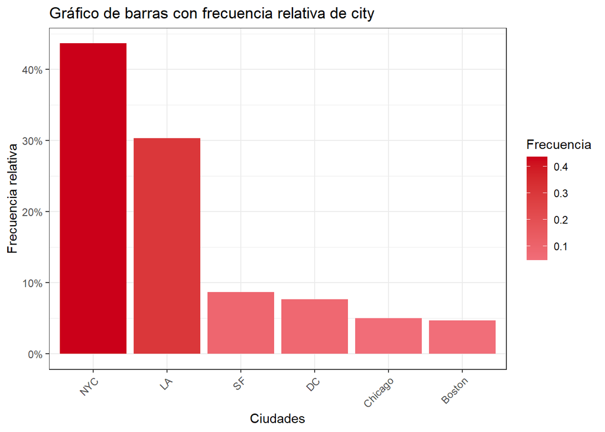

```r
Airbnb_Data  |> group_by(city) |>  summarise(Frequency = n()) |> mutate(Frequency = Frequency/sum(Frequency), city = reorder(city, -Frequency)) |> ggplot(aes(x = city, y = Frequency)) + geom_bar(stat = "identity", aes(fill = Frequency)) + scale_y_continuous(labels = scales::percent) + theme_bw() + labs(title = "Gráfico de barras con frecuencia relativa de city", x = "Ciudades", y = "Frecuencia relativa") + scale_fill_gradient("Frecuencia", low = "#F16E79", high = "#CB0019") + theme(axis.text.x = element_text(angle = 45, hjust = 1))
```

GRÁFICO DE BARRAS CON FRECUENCIA ABSOLUTA

Ahora realizaremos un gráfico de barras con frecuencia absoluta.

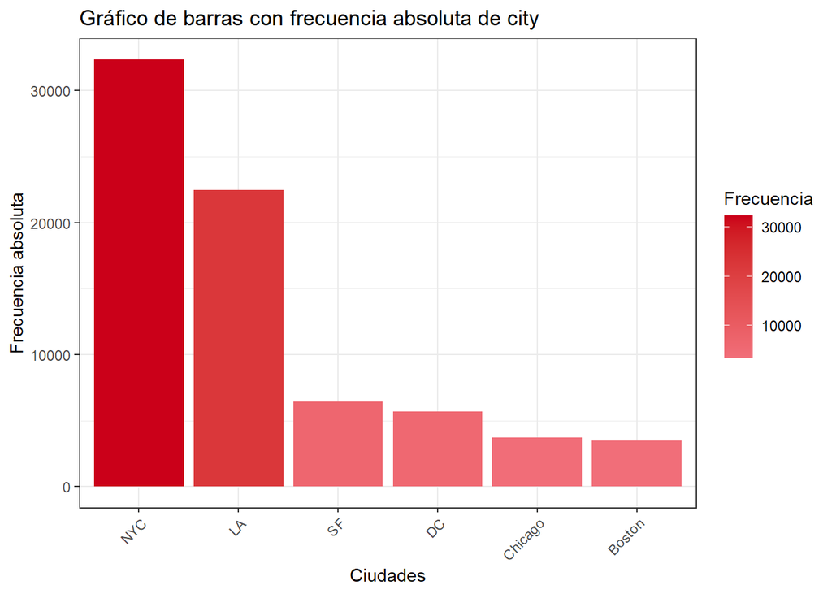

```r
Airbnb_Data  |> group_by(city) |>  summarise(Frequency = n()) |> mutate(city = reorder(city, -Frequency)) |> ggplot(aes(x = city, y = Frequency)) + geom_bar(stat = "identity", aes(fill = Frequency)) + theme_bw() + labs(title = "Gráfico de barras con frecuencia absoluta de city", x = "Ciudades", y = "Frecuencia absoluta") + scale_fill_gradient("Frecuencia", low = "#F16E79", high = "#CB0019") + theme(axis.text.x = element_text(angle = 45, hjust = 1))
```

Podemos ver que la mayor cantidad de ofertas se encuentran en Nueva York, siguiéndola medianamente de cerca Los Ángeles. Bastante por debajo se encuentran las demás cuidades, siendo por poco Boston donde hay la menor cantidad de ofertas.

#### Estudio de la variable host_identity_verified

Ahora analizaremos la variable host_identity_verified.

CONTAR EL NÚMERO DE RESPUESTAS

```r
num_respuestas_host_identity_verified <- length(unique(Airbnb_Data$host_identity_verified))
cat("El número de respuestas obtenido es: ", num_respuestas_host_identity_verified)
```

```
## El número de respuestas obtenido es:  3
```

FRECUENCIAS RELATIVAS Y ABSOLUTAS

Para hacer el análisis de esta variable vamos a estudiar su frecuencia relativa y absoluta.

```r
tabla_frec_host_identity_verified <- Airbnb_Data |> count(Airbnb_Data$host_identity_verified) |> drop_na() |> mutate(f = n/nrow(Airbnb_Data), N = cumsum(n), F = cumsum(f))
tabla_frec_ord_9 <- tabla_frec_host_identity_verified |> arrange(desc(n))
tabla_frec_ord_9$N <- cumsum(tabla_frec_ord_9$n)
tabla_frec_ord_9$F <- cumsum(tabla_frec_ord_9$f)
print(tabla_frec_ord_9)
```

```
## # A tibble: 2 × 5
##   `Airbnb_Data$host_identity_verified`     n     f     N     F
##   <lgl>                                <int> <dbl> <int> <dbl>
## 1 TRUE                                 49748 0.671 49748 0.671
## 2 FALSE                                24175 0.326 73923 0.997
```

GRÁFICO DE BARRAS CON FRECUENCIA RELATIVA

Vamos a hacer un gráfico de barras con los datos en función de su frecuencia relativa para visualizarlos mejor.

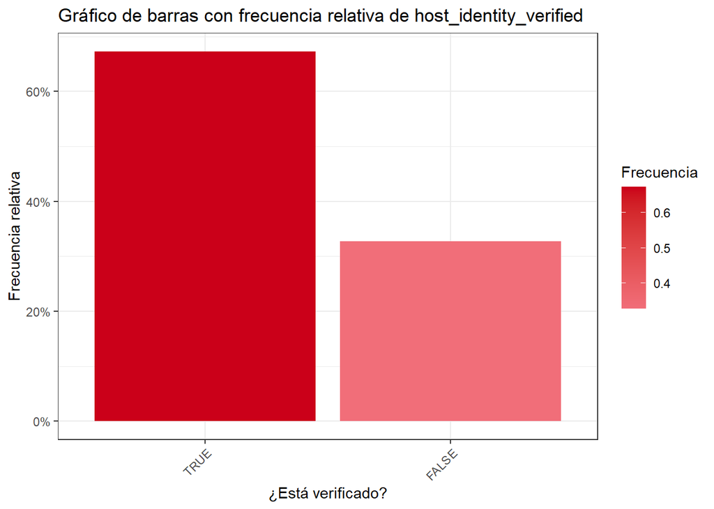

```r
Airbnb_Data  |> group_by(host_identity_verified) |>  summarise(Frequency = n()) |> drop_na() |> mutate(Frequency = Frequency/sum(Frequency), host_identity_verified = reorder(host_identity_verified, -Frequency)) |> ggplot(aes(x = host_identity_verified, y = Frequency)) + geom_bar(stat = "identity", aes(fill = Frequency)) + scale_y_continuous(labels = scales::percent) + theme_bw() + labs(title = "Gráfico de barras con frecuencia relativa de host_identity_verified", x = "¿Está verificado?", y = "Frecuencia relativa") + scale_fill_gradient("Frecuencia", low = "#F16E79", high = "#CB0019") + theme(axis.text.x = element_text(angle = 45, hjust = 1))
```

GRÁFICO DE BARRAS CON FRECUENCIA ABSOLUTA

Del mismo modo haremos otro gráfico con los datos en frecuencia absoluta.

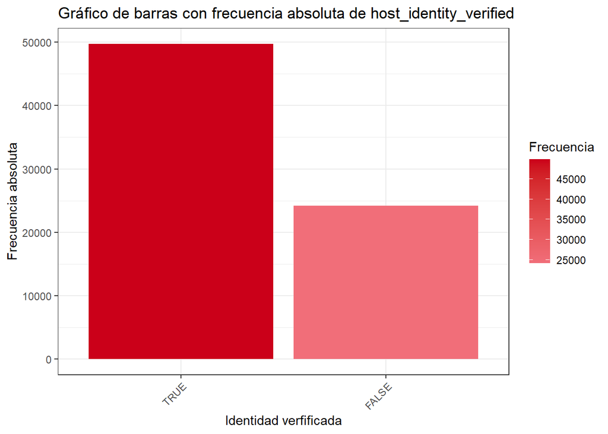

```r
Airbnb_Data  |> group_by(host_identity_verified) |>  summarise(Frequency = n()) |> drop_na() |> mutate(host_identity_verified = reorder(host_identity_verified, -Frequency)) |> ggplot(aes(x = host_identity_verified, y = Frequency)) + geom_bar(stat = "identity", aes(fill = Frequency)) + theme_bw() + labs(title = "Gráfico de barras con frecuencia absoluta de host_identity_verified", x = "Identidad verfificada", y = "Frecuencia absoluta") + scale_fill_gradient("Frecuencia", low = "#F16E79", high = "#CB0019") + theme(axis.text.x = element_text(angle = 45, hjust = 1))
```

#### Estudio de la variable instant_bookable

A continuación vamos a realizar el estudio de la variable instant_bookable.

CONTAR EL NÚMERO DE RESPUESTAS

```r
num_respuestas_instant_bookable <- length(unique(Airbnb_Data$instant_bookable))
cat("El número de respuestas obtenido es: ", num_respuestas_instant_bookable)
```

```
## El número de respuestas obtenido es:  2
```

TABLA DE FRECUENCIAS

Realizamos el estudio de su frecuencia relativa y absoluta.

```r
tabla_frec_instant_bookable <- Airbnb_Data |> count(Airbnb_Data$instant_bookable) |> mutate(f = n/nrow(Airbnb_Data), N = cumsum(n), F = cumsum(f))
tabla_frec_ord_10 <- tabla_frec_instant_bookable |> arrange(desc(n))
tabla_frec_ord_10$N <- cumsum(tabla_frec_ord_10$n)
tabla_frec_ord_10$F <- cumsum(tabla_frec_ord_10$f)
print(tabla_frec_ord_10)
```

```
## # A tibble: 2 × 5
##   `Airbnb_Data$instant_bookable`     n     f     N     F
##   <lgl>                          <int> <dbl> <int> <dbl>
## 1 FALSE                          54660 0.738 54660 0.738
## 2 TRUE                           19451 0.262 74111 1
```

GRÁFICO DE BARRAS CON FRECUENCIA RELATIVA

Para interpretar mejor los datos vamos a hacer un gráfico de barras en función de su frecuencia relativa.

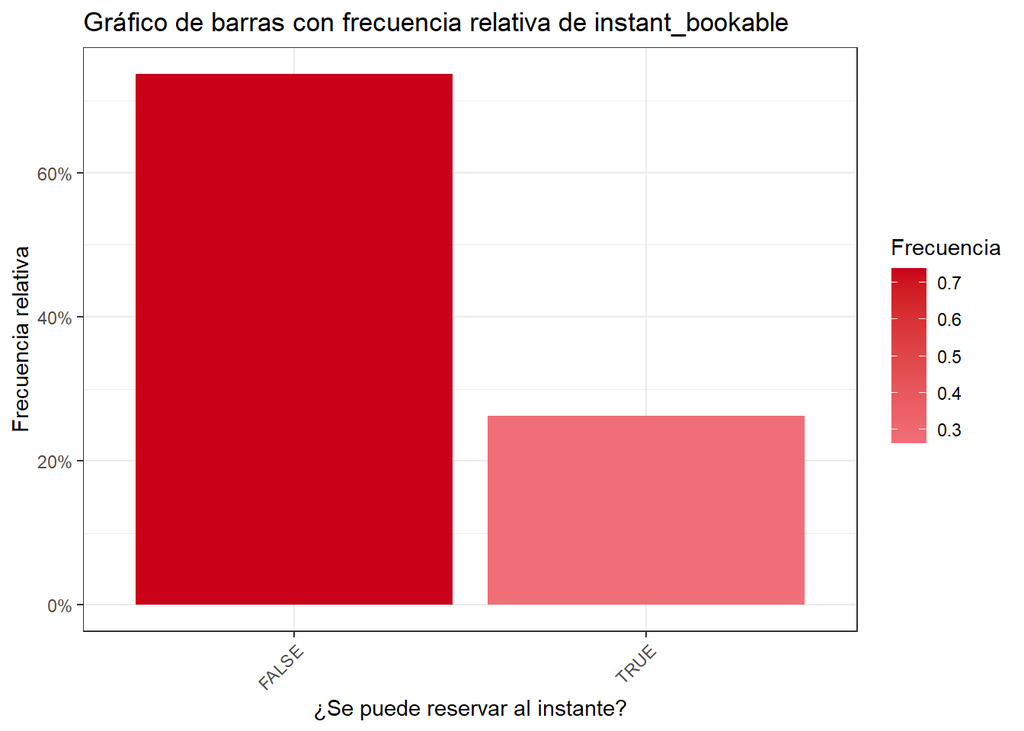

```r
Airbnb_Data  |> group_by(instant_bookable) |>  summarise(Frequency = n()) |> mutate(Frequency = Frequency/sum(Frequency), instant_bookable = reorder(instant_bookable, -Frequency)) |> ggplot(aes(x = instant_bookable, y = Frequency)) + geom_bar(stat = "identity", aes(fill = Frequency)) + scale_y_continuous(labels = scales::percent) + theme_bw() + labs(title = "Gráfico de barras con frecuencia relativa de instant_bookable", x = "¿Se puede reservar al instante?", y = "Frecuencia relativa") + scale_fill_gradient("Frecuencia", low = "#F16E79", high = "#CB0019") + theme(axis.text.x = element_text(angle = 45, hjust = 1))
```

GRÁFICO DE BARRAS CON FRECUENCIA ABSOLUTA

Y otro gráfico en función de su frecuencia absoluta.

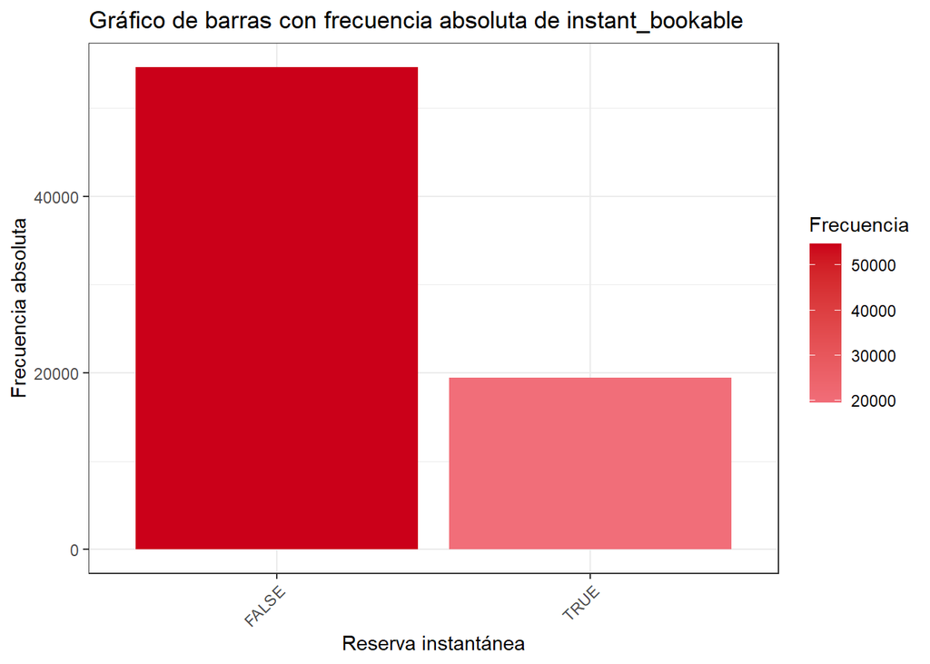

```r
Airbnb_Data  |> group_by(instant_bookable) |>  summarise(Frequency = n()) |> mutate(instant_bookable = reorder(instant_bookable, -Frequency)) |> ggplot(aes(x = instant_bookable, y = Frequency)) + geom_bar(stat = "identity", aes(fill = Frequency)) + theme_bw() + labs(title = "Gráfico de barras con frecuencia absoluta de instant_bookable", x = "Reserva instantánea", y = "Frecuencia absoluta") + scale_fill_gradient("Frecuencia", low = "#F16E79", high = "#CB0019") + theme(axis.text.x = element_text(angle = 45, hjust = 1))
```

De igual manera vemos como solo cerca de un 25% de las ofertas se pueden reservar al instante.

#### Estudio de la variable neighbourhood

A continuación, vamos a estudiar la variable neighbourhood.

CONTAR EL NÚMERO DE RESPUESTAS

```r
num_respuestas_neighbourhood <- length(unique(Airbnb_Data$neighbourhood))
cat("El número de respuestas obtenido es: ", num_respuestas_neighbourhood)
```

```
## El número de respuestas obtenido es:  620
```

Al ver que el número de respuestas es muy elevado, el análisis no nos va a resultar muy útil.

TABLA DE FRECUENCIAS

```r
tabla_frec_neighbourhood <- Airbnb_Data |> count(Airbnb_Data$neighbourhood) |> mutate(f = n/nrow(Airbnb_Data), N = cumsum(n), F = cumsum(f))
tabla_frec_ord_11 <- tabla_frec_neighbourhood |> arrange(desc(n))
tabla_frec_ord_11$N <- cumsum(tabla_frec_ord_11$n)
tabla_frec_ord_11$F <- cumsum(tabla_frec_ord_11$f)
print(tabla_frec_ord_11)
```

```
## # A tibble: 620 × 5
##    `Airbnb_Data$neighbourhood`     n      f     N      F
##    <chr>                       <int>  <dbl> <int>  <dbl>
##  1 <NA>                         6872 0.0927  6872 0.0927
##  2 Williamsburg                 2862 0.0386  9734 0.131
##  3 Bedford-Stuyvesant           2166 0.0292 11900 0.161
##  4 Bushwick                     1601 0.0216 13501 0.182
##  5 Upper West Side              1396 0.0188 14897 0.201
##  6 Mid-Wilshire                 1392 0.0188 16289 0.220
##  7 Harlem                       1374 0.0185 17663 0.238
##  8 Hollywood                    1321 0.0178 18984 0.256
##  9 Hell's Kitchen               1299 0.0175 20283 0.274
## 10 Venice                       1222 0.0165 21505 0.290
## # ℹ 610 more rows
```

Vamos a realizar un gráfico de barras con frecuencia relativa.

GRÁFICO DE BARRAS CON FRECUENCIA RELATIVA

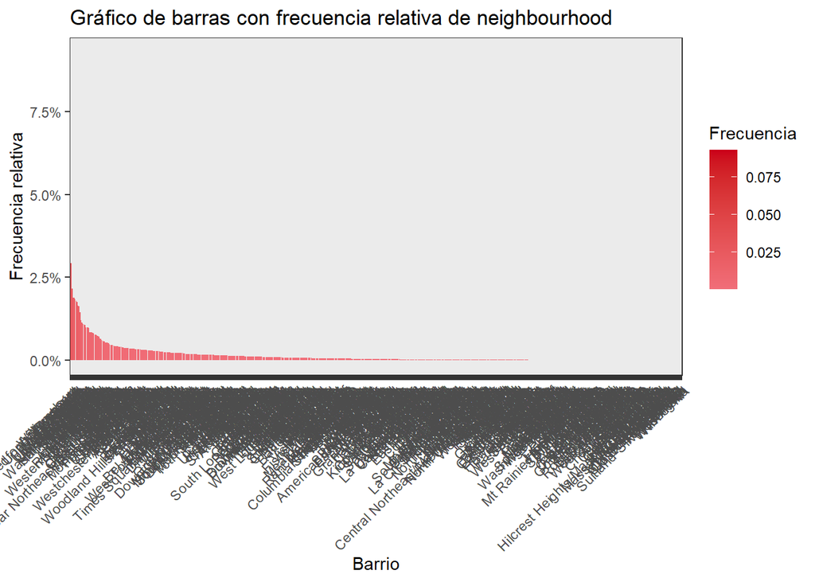

```r
Airbnb_Data  |> group_by(neighbourhood) |>  summarise(Frequency = n())  |>  mutate(Frequency = Frequency/sum(Frequency), neighbourhood = reorder(neighbourhood, -Frequency)) |> ggplot(aes(x = neighbourhood, y = Frequency)) + geom_bar(stat = "identity", aes(fill = Frequency)) + scale_y_continuous(labels = scales::percent) + theme_bw() + labs(title = "Gráfico de barras con frecuencia relativa de neighbourhood", x = "Barrio", y = "Frecuencia relativa") + scale_fill_gradient("Frecuencia", low = "#F16E79", high = "#CB0019") + theme(axis.text.x = element_text(angle = 45, hjust = 1))
```

Del mismo modo hacemos otro gráfico de barras con la frecuencia absoluta.

GRÁFICO DE BARRAS CON FRECUENCIA ABSOLUTA

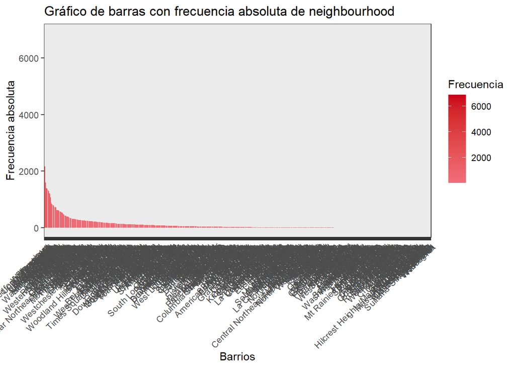

```r
Airbnb_Data  |> group_by(neighbourhood) |>  summarise(Frequency = n()) |>  mutate(neighbourhood = reorder(neighbourhood, -Frequency)) |> ggplot(aes(x = neighbourhood, y = Frequency)) + geom_bar(stat = "identity", aes(fill = Frequency)) + theme_bw() + labs(title = "Gráfico de barras con frecuencia absoluta de neighbourhood", x = "Barrios", y = "Frecuencia absoluta") + scale_fill_gradient("Frecuencia", low = "#F16E79", high = "#CB0019") + theme(axis.text.x = element_text(angle = 45, hjust = 1))
```

Como podemos observar hay tantos datos que el análisis es ilegible y además llega un momento que la información se pierde, por lo que hemos decidido hacer otras dos gráficas con solo los barrios que cuentan con más de 300 ofertas en la plataforma.

GRÁFICO DE BARRAS CON FRECUENCIA RELATIVA DE LOS BARRIOS CON MÁS DE 300 OFERTAS

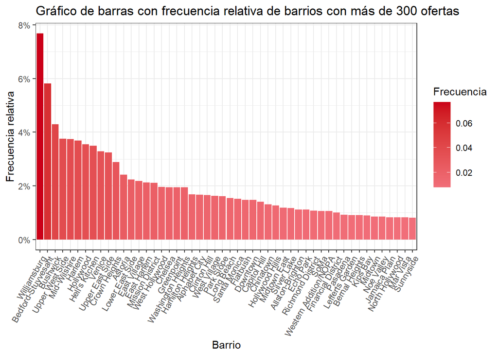

```r
Airbnb_Data  |> group_by(neighbourhood) |>  summarise(Frequency = n())  |>  drop_na() |> filter(Frequency > 300)|>mutate(Frequency = Frequency/sum(Frequency), neighbourhood = reorder(neighbourhood, -Frequency)) |> ggplot(aes(x = neighbourhood, y = Frequency)) + geom_bar(stat = "identity", aes(fill = Frequency)) + scale_y_continuous(labels = scales::percent) + theme_bw() + labs(title = "Gráfico de barras con frecuencia relativa de barrios con más de 300 ofertas ", x = "Barrio", y = "Frecuencia relativa") + scale_fill_gradient("Frecuencia", low = "#F16E79", high = "#CB0019") + theme(axis.text.x = element_text(angle = 60, hjust = 1))
```

GRÁFICO DE BARRAS CON FRECUENCIA ABSOLUTA DE LOS BARRIOS CON MÁS DE 300 OFERTAS

[figure not shown]

```r
Airbnb_Data  |> group_by(neighbourhood) |>  summarise(Frequency = n()) |> drop_na() |> filter(Frequency > 300)|> mutate(neighbourhood = reorder(neighbourhood, -Frequency)) |> ggplot(aes(x = neighbourhood, y = Frequency)) + geom_bar(stat = "identity", aes(fill = Frequency)) + theme_bw() + labs(title = "Gráfico de barras con frecuencia absoluta de barrios con más de 3000 ofertas", x = "Barrios", y = "Frecuencia absoluta") + scale_fill_gradient("Frecuencia", low = "#F16E79", high = "#CB0019") + theme(axis.text.x = element_text(angle = 60, hjust = 1))
```

Después de analizar solo los barrios con más de 300 ofertas, vemos que la mayor parte de estas se encuentran en Williamsburg (Nueva York) con un 3.9 % del total, sumando casi 3000 ofertas, seguido de Bedford-Stuyvesant (Nueva York), con más de 2000 ofertas y de Bushwick (Nueva York), superando las 1500 ofertas. Con todo ello se puede observar que los 3 barrios con más ofertas se encuentra en Nueva York.

#### Estudio de la variable number_of_reviews

Aquí vamos a realizar el estudio de la variable number_of_reviews

CONTAR EL NÚMERO DE RESPUESTAS

```r
num_respuestas_number_of_reviews <- length(unique(Airbnb_Data$number_of_reviews))
cat("La cantidad de respuestas obtenidas es:", num_respuestas_number_of_reviews)
```

```
## La cantidad de respuestas obtenidas es: 371
```

TABLA DE FRECUENCIAS

Estudiamos las frecuencias relativas y absolutas con la tabla de frecuencias, dividiendo los valores en rangos de 20 por la gran cantidad de respuestas que hay en esta variable.

```r
intervalos <- seq(0, ceiling(max(Airbnb_Data$number_of_reviews)/20) * 20, by = 20)
tabla_frecuencias_number_of_reviews <- Airbnb_Data |> count(number_of_reviews) |> drop_na() |> mutate(f = n / nrow(Airbnb_Data), N = cumsum(n), F = cumsum(f))
 tabla_frecuencias_number_of_reviews <- tabla_frecuencias_number_of_reviews |> mutate(Intervalo = cut(number_of_reviews, breaks = intervalos, right = FALSE)) |> group_by(Intervalo) |> summarise (n = sum(n), f = sum(f), N = sum(n), F = sum(f))
 for (i in 2: nrow(tabla_frecuencias_number_of_reviews)) {
   tabla_frecuencias_number_of_reviews$N[i] <- tabla_frecuencias_number_of_reviews$N[i] + tabla_frecuencias_number_of_reviews$N[i-1]
    tabla_frecuencias_number_of_reviews$F[i] <- tabla_frecuencias_number_of_reviews$F[i] + tabla_frecuencias_number_of_reviews$F[i-1]}
 tabla_frecuencias_ordenada12 <- tabla_frecuencias_number_of_reviews |> arrange(Intervalo)
 print(tabla_frecuencias_ordenada12)
```

```
## # A tibble: 29 × 5
##    Intervalo     n       f     N     F
##    <fct>     <int>   <dbl> <int> <dbl>
##  1 [0,20)    53291 0.719   53291 0.719
##  2 [20,40)    8745 0.118   62036 0.837
##  3 [40,60)    4394 0.0593  66430 0.896
##  4 [60,80)    2617 0.0353  69047 0.932
##  5 [80,100)   1641 0.0221  70688 0.954
##  6 [100,120)  1081 0.0146  71769 0.968
##  7 [120,140)   724 0.00977 72493 0.978
##  8 [140,160)   534 0.00721 73027 0.985
##  9 [160,180)   358 0.00483 73385 0.990
## 10 [180,200)   197 0.00266 73582 0.993
## # ℹ 19 more rows
```

HISTOGRAMA DE NÚMERO DE REVIEWS

Para poder interpretar bien los datos vamos a hacer un histograma y un análisis numérico.

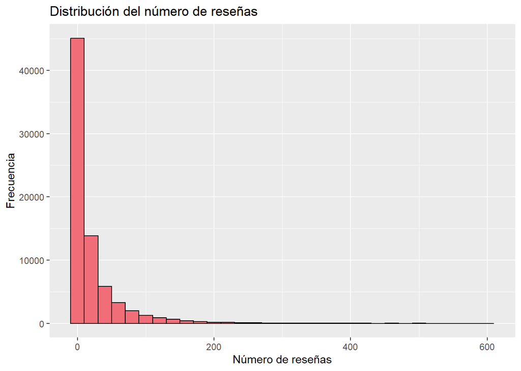

```r
datos <- Airbnb_Data$number_of_reviews
 ggplot(data.frame(x = datos), aes(x = x)) +
     geom_histogram(binwidth = 20, fill = "#F16E79", color = "black",
                    ) +

     labs(title = "Distribución del número de reseñas",
          x = "Número de reseñas",
          y = "Frecuencia")
```

RESUMEN NUMÉRICO DEL NÚMERO DE REVIEWS

```r
Airbnb_Data |> select(number_of_reviews) |> descr() |> kable(digits = 2)
```

|  | number_of_reviews |
| --- | --- |
| Mean | 20.90 |
| Std.Dev | 37.83 |
| Min | 0.00 |
| Q1 | 1.00 |
| Median | 6.00 |
| Q3 | 23.00 |
| Max | 605.00 |
| MAD | 8.90 |
| IQR | 22.00 |
| CV | 1.81 |
| Skewness | 3.70 |
| SE.Skewness | 0.01 |
| Kurtosis | 20.65 |
| N.Valid | 74111.00 |
| Pct.Valid | 100.00 |

Se puede observar que hay bastantes pocos casos en los que se muestran más de 100 reseñas, siendo así que la media de reviews por propiedad es de casi 21. Sin embargo, hay propiedades con entre 0 y 605 reseñas.

#### Estudio de la variable review_scores_rating

A continuación, vamos a analizar la variable review_score_rating.

CONTAR EL NÚMERO DE RESPUESTAS

```r
num_respuestas_review_scores_rating <- length(unique (Airbnb_Data$review_scores_rating))
cat("La cantidad de respuestas obtenidas es:", num_respuestas_review_scores_rating)
```

```
## La cantidad de respuestas obtenidas es: 55
```

TABLA DE FRECUENCIAS

Estudiamos las frecuencias relativas y absolutas.

```r
tabla_frecuencias_review_scores_rating <- Airbnb_Data |> drop_na() |>count(review_scores_rating) |> mutate(f = n / nrow(Airbnb_Data), N = cumsum(n), F = cumsum(f))
tabla_frecuencias_ordenada13 <- tabla_frecuencias_review_scores_rating |>
    arrange(desc(n))
 tabla_frecuencias_ordenada13$F <- cumsum(tabla_frecuencias_ordenada5$f)
```

[output not shown]

```r
 tabla_frecuencias_ordenada13$N <- cumsum(tabla_frecuencias_ordenada5$n)
```

[output not shown]

```r
 print(tabla_frecuencias_ordenada13)
```

```
## # A tibble: 52 × 5
##    review_scores_rating     n      f     N     F
##                   <dbl> <int>  <dbl> <int> <dbl>
##  1                  100  9261 0.125  38502 0.520
##  2                   98  3373 0.0455 27110 0.366
##  3                   97  3092 0.0417 23737 0.320
##  4                   96  3057 0.0412 20645 0.279
##  5                   95  2707 0.0365 17588 0.237
##  6                   93  2494 0.0337 12872 0.174
##  7                   99  2131 0.0288 29241 0.395
##  8                   94  2009 0.0271 14881 0.201
##  9                   90  1691 0.0228  7592 0.102
## 10                   92  1550 0.0209 10378 0.140
## # ℹ 42 more rows
```

HISTOGRAMA DE LA PUNTUACIÓN DE REVIEWS

Primero vamos a hacer un histograma de los datos para poder visualizarlos mejor.

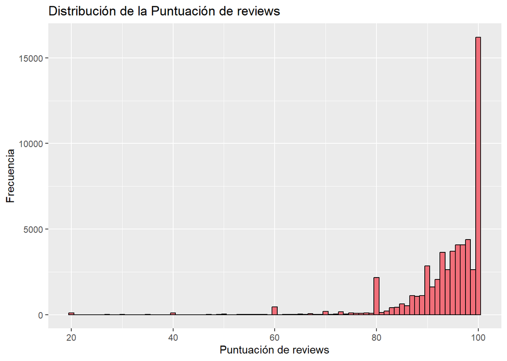

```r
datos <- Airbnb_Data$review_scores_rating
 ggplot(data.frame(x = datos), aes(x = x)) +
     geom_histogram(binwidth = 1, fill = "#F16E79", color = "black",
                    ) +

     labs(title = "Distribución de la Puntuación de reviews",
          x = "Puntuación de reviews",
          y = "Frecuencia")
```

Se puede ver como las propiedades con puntuaciones de entre 90 y 100 predominan, además de que las que tiene una valoración por debajo de 80 son despreciables.

RESUMEN NUMÉRICO DE LA PUNTUACIÓN DE REVIEWS

Y después hacemos un análisis numérico.

```r
Airbnb_Data |> select(review_scores_rating) |> descr() |> kable(digits = 2)
```

|  | review_scores_rating |
| --- | --- |
| Mean | 94.07 |
| Std.Dev | 7.84 |
| Min | 20.00 |
| Q1 | 92.00 |
| Median | 96.00 |
| Q3 | 100.00 |
| Max | 100.00 |
| MAD | 5.93 |
| IQR | 8.00 |
| CV | 0.08 |
| Skewness | -3.38 |
| SE.Skewness | 0.01 |
| Kurtosis | 20.02 |
| N.Valid | 57389.00 |
| Pct.Valid | 77.44 |

Después de analizar la variable, al haber visto que la gran mayoría de puntuaciones son altas, la media está en torno a 94 y la mediana es de 96. Aunque también se ve que la puntación no baja nunca de 20.

### Análisis bivariante:

#### Estudio de las variables bedrooms, bathrooms, price y beds

En primer lugar, vamos a realizar un estudio de la correlación y la covarianza entre las variables bedrooms, bathrooms, price y beds, proporcionando una visión de cómo varían conjuntamente las variables.

MATRIZ DE CORRELACIÓN

```r
Airbnb_Data |> select(bedrooms, bathrooms, log_price, beds) |>
    drop_na() |>
    cor() |>
    round(2)
```

```
##           bedrooms bathrooms log_price beds
## bedrooms      1.00      0.59      0.49 0.71
## bathrooms     0.59      1.00      0.46 0.53
## log_price     0.49      0.46      1.00 0.43
## beds          0.71      0.53      0.43 1.00
```

MATRIZ DE COVARIANZA

```r
Airbnb_Data |> select(bedrooms, bathrooms, log_price, beds) |>
    drop_na() |>
    cov() |>
    round(2)
```

```
##           bedrooms bathrooms log_price  beds
## bedrooms      0.73      0.29     71.18  0.76
## bathrooms     0.29      0.34     45.17  0.38
## log_price    71.18     45.17  28487.74 91.75
## beds          0.76      0.38     91.75  1.58
```

Ahora realizaremos un gráfico con los datos ya mostrados para poder entenderlos mejor.

GRÁFICO DE CORRELACIÓN NUMÉRICA

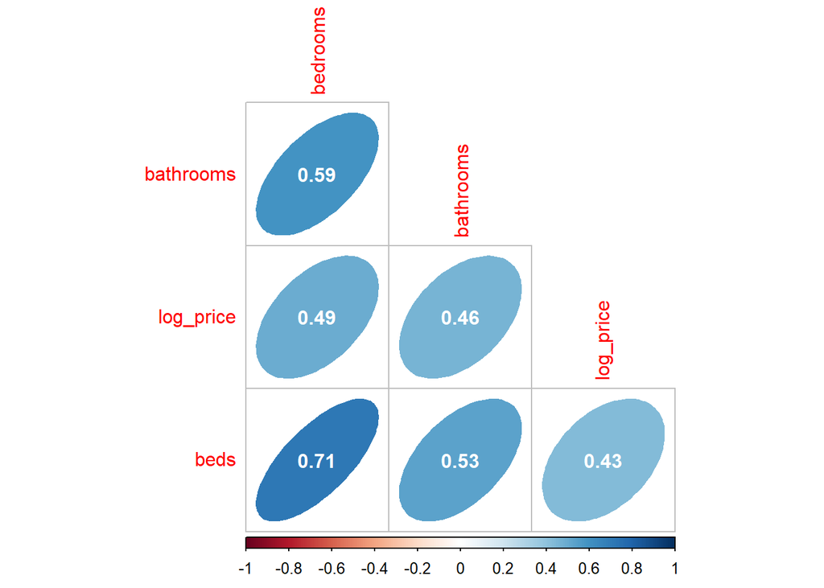

```r
Airbnb_Data |>
    select(bedrooms, bathrooms, log_price, beds) |>
    drop_na() |>
    cor() |>
    round(2) |>
    corrplot(method = "ellipse",  type = "lower",      addCoef.col = "white", diag = FALSE)
```

Podemos observar que la correlación entre el precio y el resto de variables no es tan elevado por la gran cantidad de valores atípicos que posee nuestra base de datos, sin embargo, es suficiente como para estudiar la relación. Podemos observar como hay una mayor correlación entre el número de habitaciones y el número de baños, y sobre todo entre el número de habitaciones y el número de camas como es lógico. La relación entre el número de habitaciones y el de camas, nos ayuda a ver que cuantas más habitaciones, más personas pueden alojarse en la casa, ya que aumenta también el número de camas y no suelen ser habitaciones “vacías”.

#### Estudio de las variables bedrooms y price

TABLA DE CONTINGENCIA ENTRE LAS VARIABLES BEDROOMS Y PRICE RELATIVA

No mostramos la tabla porque la abundancia de datos hace que sea inmensamente grande, pero hacemos un gráfico de dispersión de regresión lineal.

GRÁFICO DE DISPERSIÓN CON AJUSTE DE REGRESIÓN LINEAL

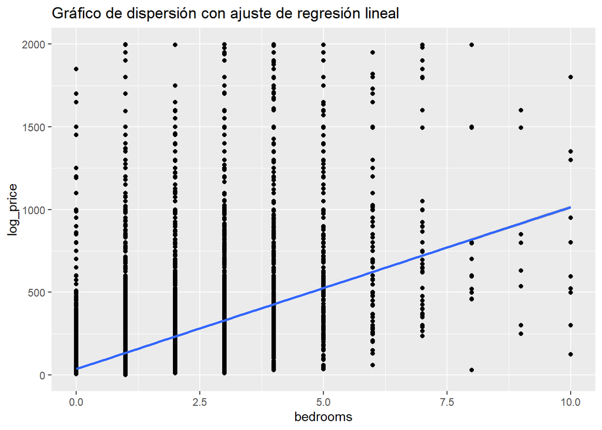

```r
Airbnb_Data |>
    ggplot(aes(x = bedrooms, y = log_price)) +
    geom_point() +
    geom_smooth(method = lm) +
    labs(title = "Gráfico de dispersión con ajuste de regresión lineal")
```

Podemos ver en la gráfica que hay un aumento general del precio de la propiedad según las habitaciones que haya. No obstante, hay una abundancia de datos atípicos hacen un tanto confuso el gráfico, pero aun así se puede identificar de manera correcta el aumento del precio de la propiedad a la par que las habitaciones. No obstante vamos a realizar unos cálculos que nos serán de utilidad para compender mejor la realción.

```r
lineal_1 <- Airbnb_Data |> drop_na() |>
  select(bedrooms, log_price) |>
  with(lm(bedrooms ~ log_price))
summary(lineal_1)
```

```
##
## Call:
## lm(formula = bedrooms ~ log_price)
##
## Residuals:
##     Min      1Q  Median      3Q     Max
## -6.0725 -0.2344 -0.0197  0.1210  8.8219
##
## Coefficients:
##              Estimate Std. Error t value Pr(>|t|)
## (Intercept) 7.382e-01  5.336e-03   138.3   <2e-16 ***
## log_price   3.519e-03  2.721e-05   129.3   <2e-16 ***
## ---
## Signif. codes:  0 '***' 0.001 '**' 0.01 '*' 0.05 '.' 0.1 ' ' 1
##
## Residual standard error: 0.6984 on 38500 degrees of freedom
## Multiple R-squared:  0.3029, Adjusted R-squared:  0.3029
## F-statistic: 1.673e+04 on 1 and 38500 DF,  p-value: < 2.2e-16
```

Con estos resultados corroboramos que la abrumadora cantidad de respuestas variadas en cuanto al precio, los datos erróneos son un tanto altos. Esto no quita que exista cierta correlación entre ambas variables, la variable habitaciones explica un 30,29% del precio.

#### Estudio de las variables bedrooms y bathrooms

Para llevar a cabo este estudio primero realizamos dos tablas de contingencia, una relativa y otra absoluta.

TABLA DE CONTINGENCIA ENTRE BEDROOMS Y BATHROOMS RELATIVA

```r
kable(prop.table(table(Airbnb_Data$bedrooms, Airbnb_Data$bathrooms)), digits = 6)
```

|  | 0 | 0.5 | 1 | 1.5 | 2 | 2.5 | 3 | 3.5 | 4 | 4.5 | 5 | 5.5 | 6 | 6.5 | 7 | 7.5 | 8 |
| --- | --- | --- | --- | --- | --- | --- | --- | --- | --- | --- | --- | --- | --- | --- | --- | --- | --- |
| 0 | 0.000366 | 0.000217 | 0.089225 | 0.000325 | 0.000528 | 0.000054 | 0.000081 | 0.000054 | 0.000054 | 0.000014 | 0.000000 | 0.000000 | 1.4e-05 | 0.0e+00 | 0.0e+00 | 0.0e+00 | 0.000027 |
| 1 | 0.002289 | 0.002574 | 0.590735 | 0.034311 | 0.032482 | 0.004131 | 0.003224 | 0.000501 | 0.000989 | 0.000054 | 0.000163 | 0.000027 | 4.1e-05 | 2.7e-05 | 0.0e+00 | 0.0e+00 | 0.000393 |
| 2 | 0.000027 | 0.000027 | 0.089577 | 0.011134 | 0.045906 | 0.005513 | 0.001138 | 0.000176 | 0.000108 | 0.000000 | 0.000000 | 0.000000 | 0.0e+00 | 0.0e+00 | 0.0e+00 | 0.0e+00 | 0.000000 |
| 3 | 0.000000 | 0.000014 | 0.014805 | 0.004863 | 0.022282 | 0.008263 | 0.005513 | 0.001923 | 0.000461 | 0.000135 | 0.000041 | 0.000014 | 0.0e+00 | 0.0e+00 | 0.0e+00 | 0.0e+00 | 0.000000 |
| 4 | 0.000000 | 0.000000 | 0.001382 | 0.000704 | 0.005229 | 0.002750 | 0.003251 | 0.002465 | 0.001165 | 0.000623 | 0.000271 | 0.000108 | 2.7e-05 | 0.0e+00 | 1.4e-05 | 0.0e+00 | 0.000000 |
| 5 | 0.000000 | 0.000000 | 0.000108 | 0.000108 | 0.000786 | 0.000433 | 0.000813 | 0.000582 | 0.000664 | 0.000555 | 0.000298 | 0.000325 | 4.1e-05 | 6.8e-05 | 0.0e+00 | 1.4e-05 | 0.000014 |
| 6 | 0.000000 | 0.000000 | 0.000000 | 0.000014 | 0.000203 | 0.000068 | 0.000325 | 0.000068 | 0.000257 | 0.000122 | 0.000095 | 0.000041 | 9.5e-05 | 4.1e-05 | 4.1e-05 | 2.7e-05 | 0.000041 |
| 7 | 0.000000 | 0.000000 | 0.000000 | 0.000000 | 0.000068 | 0.000000 | 0.000027 | 0.000041 | 0.000081 | 0.000068 | 0.000054 | 0.000014 | 5.4e-05 | 1.4e-05 | 2.7e-05 | 2.7e-05 | 0.000041 |
| 8 | 0.000000 | 0.000000 | 0.000000 | 0.000000 | 0.000014 | 0.000014 | 0.000027 | 0.000000 | 0.000027 | 0.000000 | 0.000027 | 0.000000 | 2.7e-05 | 1.4e-05 | 2.7e-05 | 1.4e-05 | 0.000000 |
| 9 | 0.000000 | 0.000000 | 0.000000 | 0.000000 | 0.000000 | 0.000000 | 0.000041 | 0.000000 | 0.000041 | 0.000000 | 0.000014 | 0.000000 | 1.4e-05 | 0.0e+00 | 0.0e+00 | 0.0e+00 | 0.000000 |
| 10 | 0.000000 | 0.000000 | 0.000014 | 0.000000 | 0.000000 | 0.000000 | 0.000000 | 0.000000 | 0.000027 | 0.000000 | 0.000014 | 0.000000 | 1.4e-05 | 0.0e+00 | 2.7e-05 | 0.0e+00 | 0.000041 |

TABLA DE CONTINGENCIA ENTRE BEDROOMS Y BATHROOMS ABSOLUTA

```r
kable(table(Airbnb_Data$bedrooms, Airbnb_Data$bathrooms))
```

|  | 0 | 0.5 | 1 | 1.5 | 2 | 2.5 | 3 | 3.5 | 4 | 4.5 | 5 | 5.5 | 6 | 6.5 | 7 | 7.5 | 8 |
| --- | --- | --- | --- | --- | --- | --- | --- | --- | --- | --- | --- | --- | --- | --- | --- | --- | --- |
| 0 | 27 | 16 | 6587 | 24 | 39 | 4 | 6 | 4 | 4 | 1 | 0 | 0 | 1 | 0 | 0 | 0 | 2 |
| 1 | 169 | 190 | 43611 | 2533 | 2398 | 305 | 238 | 37 | 73 | 4 | 12 | 2 | 3 | 2 | 0 | 0 | 29 |
| 2 | 2 | 2 | 6613 | 822 | 3389 | 407 | 84 | 13 | 8 | 0 | 0 | 0 | 0 | 0 | 0 | 0 | 0 |
| 3 | 0 | 1 | 1093 | 359 | 1645 | 610 | 407 | 142 | 34 | 10 | 3 | 1 | 0 | 0 | 0 | 0 | 0 |
| 4 | 0 | 0 | 102 | 52 | 386 | 203 | 240 | 182 | 86 | 46 | 20 | 8 | 2 | 0 | 1 | 0 | 0 |
| 5 | 0 | 0 | 8 | 8 | 58 | 32 | 60 | 43 | 49 | 41 | 22 | 24 | 3 | 5 | 0 | 1 | 1 |
| 6 | 0 | 0 | 0 | 1 | 15 | 5 | 24 | 5 | 19 | 9 | 7 | 3 | 7 | 3 | 3 | 2 | 3 |
| 7 | 0 | 0 | 0 | 0 | 5 | 0 | 2 | 3 | 6 | 5 | 4 | 1 | 4 | 1 | 2 | 2 | 3 |
| 8 | 0 | 0 | 0 | 0 | 1 | 1 | 2 | 0 | 2 | 0 | 2 | 0 | 2 | 1 | 2 | 1 | 0 |
| 9 | 0 | 0 | 0 | 0 | 0 | 0 | 3 | 0 | 3 | 0 | 1 | 0 | 1 | 0 | 0 | 0 | 0 |
| 10 | 0 | 0 | 1 | 0 | 0 | 0 | 0 | 0 | 2 | 0 | 1 | 0 | 1 | 0 | 2 | 0 | 3 |

Y en segundo lugar vamos a hacer un gráfico de dispersión con ajuste de regresión lineal con los datos obtenidos

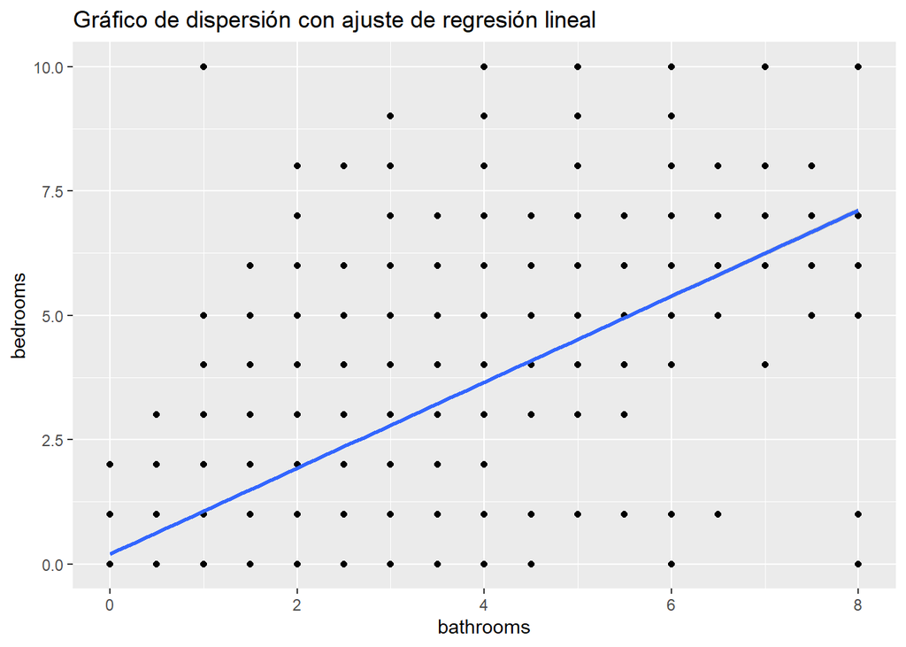

```r
Airbnb_Data |>
    ggplot(aes(x = bathrooms, y = bedrooms)) +
    geom_point() +
    geom_smooth(method = lm) +
    labs(title = "Gráfico de dispersión con ajuste de regresión lineal")
```

También hemos realizado los siguientes cálculos que nos aportan información útil para el análisis.

```r
lineal_1 <- Airbnb_Data |> drop_na() |>
  select(bedrooms, bathrooms) |>
  with(lm(bedrooms ~ bathrooms))
summary(lineal_1)
```

```
##
## Call:
## lm(formula = bedrooms ~ bathrooms)
##
## Residuals:
##     Min      1Q  Median      3Q     Max
## -6.6911 -0.0799 -0.0799 -0.0799  8.9201
##
## Coefficients:
##             Estimate Std. Error t value Pr(>|t|)
## (Intercept) 0.278301   0.008760   31.77   <2e-16 ***
## bathrooms   0.801600   0.006565  122.11   <2e-16 ***
## ---
## Signif. codes:  0 '***' 0.001 '**' 0.01 '*' 0.05 '.' 0.1 ' ' 1
##
## Residual standard error: 0.7102 on 38500 degrees of freedom
## Multiple R-squared:  0.2792, Adjusted R-squared:  0.2791
## F-statistic: 1.491e+04 on 1 and 38500 DF,  p-value: < 2.2e-16
```

Como podemos ver, la gráfica posee una regresión lineal esperable, a cuantas más habitaciones haya, mayor es el número de baños, a pesar de la gran cantidad de valores atípicos que hay.

Hablando de datos erróneos, estos son una minoría en comparación con la gran mayoría de valores presentes.

Por último, vemos que la variable bedrooms explica el 27,9% de la variabilidad de bathroom, lo cual no nos resulta muy útil ya que entonces el resultado obtenido en el estudio no es muy fiable ya que no es un valor muy elevado.

Aun así, debido al aumento de habitaciones respecto a los baños, podemos deducir que cuantos más baños/habitaciones haya, más grande será la propiedad. Con esto, y habiendo visto anteriormente que la variable del precio aumenta según sube la cantidad de habitaciones, podemos deducir por lógica que el precio también aumenta según el tamaño de la propiedad. Esto significa que, gracias a haber comparado anteriormente las habitaciones y el número de camas, cuantas más personas se puedan alojar, mayor será el precio de la propiedad.

#### Estudio de las variables price y city

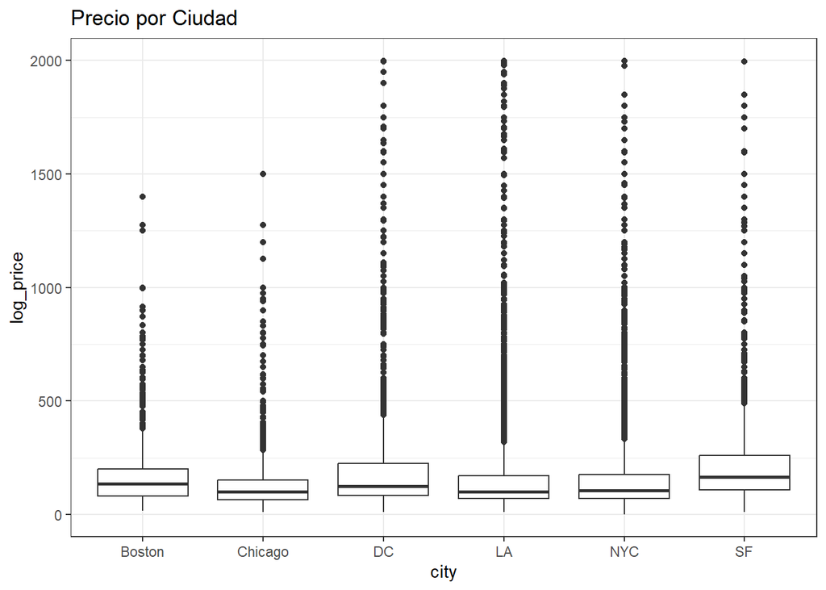

```r
Airbnb_Data |>
  ggplot(aes(x = city, y = log_price)) +
  geom_boxplot() +
  theme_bw() +
  labs(title = "Precio por Ciudad")
```

Gracias a este gráfico vemos que todas las ciudades presentan muchos valores atípicos, llegando hasta los 2000$, salvo Boston y Chicago que tiene menos que el resto, llegando a los 1500$, por lo tanto para poder estudiar mejor estas variables vamos a realizar otro box-plot centrándonos en los precios de menos de 500$.

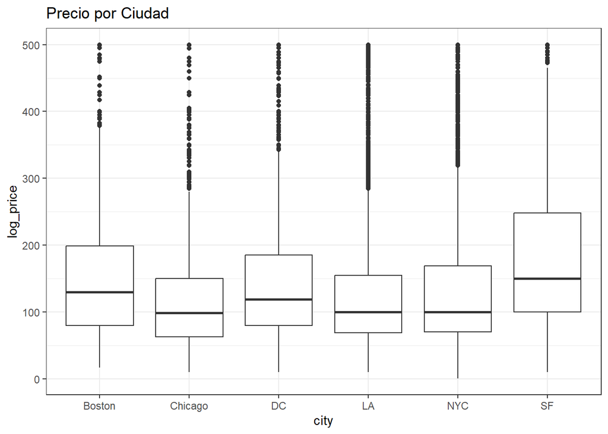

```r
Airbnb_Data |> filter(log_price < 500) |>
  ggplot(aes(x = city, y = log_price)) +
  geom_boxplot() +
  theme_bw() +
  labs(title = "Precio por Ciudad")
```

Podemos ver con más claridad como los precios más caros nos los encontramos en San Francisco y los más baratos en Los Ángeles y Chicago.

## Conclusión

Tras el análisis de los datos, hemos llegado a las siguientes conclusiones:

El objetivo principal de este estudio era analizar cómo varía el precio de las ofertas de Airbnb según las diferentes variables del conjunto de datos. Sin embargo, concluimos que la mayoría de las variables que podrían haber sido relevantes, presentan un coeficiente de correlación lineal bajo, lo que dificulta su análisis y limita la obtención de resultados significativos.

En el análisis univariante, se descartaron algunas variables debido a su escasa relevancia o la falta de información suficiente en ellas. Además, para el análisis bivariante, el tipo de propiedad quizás hubiera influenciado en el precio, no obstante, después de analizar la variable de forma univariante, concluimos que para que el bajo número de diferentes propiedades a parte de las 2 principales, no sería de gran relevancia para el análisis.

A pesar de ello, se identificaron varias variables con una buena correlación lineal entre sí. Se pudo concluir que, efectivamente, el precio aumenta según aumenta la gente que pueda alojarse en la propiedad y según aumenta el tamaño de la misma, cosa que parece ser importante a la hora de reservar en esta plataforma.

Cabe destacar que el estudio se ha visto ligeramente afectado negativamente debido a que, al haber tantas respuestas, hay una gran variedad en los datos, lo que ha impactado en la calidad de los resultados obtenidos, pero que aun así se han logrado obtener unas conclusiones válidas para el estudio.